# Восстановление золота из руды

Подготовьте прототип модели машинного обучения для «Цифры». Компания разрабатывает решения для эффективной работы промышленных предприятий.

Модель должна предсказать коэффициент восстановления золота из золотосодержащей руды. Используйте данные с параметрами добычи и очистки.

Модель поможет оптимизировать производство, чтобы не запускать предприятие с убыточными характеристиками.

Вам нужно:

1. Подготовить данные;
2. Провести исследовательский анализ данных;
3. Построить и обучить модель.

Чтобы выполнить проект, обращайтесь к библиотекам *pandas*, *matplotlib* и *sklearn.* Вам поможет их документация.

**Задачи:**

1. Загрузить и подготовьте данные.
2. Провести переработку
3. Провести исследовательский анализ данных
4. Подготовить данные для МО
5. Напишите функцию для вычисления итоговой sMAPE.
6. Провести кросс валидацию для выбора лучшей модели по метрике sMAPE.
7. Проверить работу модели на контрольной выборке

**План:**

1. Загрузить файлы, ознакомится с особенностями исходных данных и выборок
2. Переработка данных
3. Исследовательский анализ данных
4. Подготовить данные для МО
   - Разбить на выборки и ЦП для двух ЦП: Эффективность обогащения флотации и очистки в целом
   - Масштабировать
5. Составить функцию для вычисления итоговой sMAPE
6. Провести кросс валидацию для выбора лучшей модели по метрике sMAPE.
   - Для флотации
   - Для очистки в целом
   - Сосчитать итоговый sMAPE обучающей выборки для лучших моделей
7. Сосчитать итоговый sMAPE контрольной выборки на основе лучших моделей
8. Заключение

**Содержание**

1. Подготовка данных  
   1.1. Загрзка  
   1.2. Эфективность обогощения  
   1.3. Признаки, недоступные в тестовой выборке  
   1.4. Предобработка данных.  
   1.4.1. Пропуски  
   1.4.2. Дубликаты  
   1.4.3. Типы данных
2. Анализ данных  
   2.1. Столбец Дат  
   2.2. Концентрация металлов (Au, Ag, Pb) на различных этапах  
   2.3. Распределение целевых признаков `recovery`  
   2.4. Распределения размеров гранул исходного сырья на обучающей и тестовой выборках  
   2.5. Суммарная концентрация металлов на разных стадиях  
   2.6. Итоги Анализа
3. Модель  
   3.1. Выборки  
   3.2. StandardScaler  
   3.3. Функция для вычисления итоговой sMAPE.  
   3.4. Кросс-валидация  
   3.5. Контрольная выборка  
   3.6. Проверка на вменяемость
4. Заключение

```python
import pandas as pd
import matplotlib.pyplot as plt
import seaborn as sns
import numpy as np
import time
import os

from sklearn.preprocessing import StandardScaler
from sklearn.metrics import mean_absolute_error
from sklearn.metrics import make_scorer
from sklearn.model_selection import cross_val_score
from sklearn.model_selection import GridSearchCV

from sklearn.linear_model import LinearRegression
from sklearn.tree import DecisionTreeRegressor
from sklearn.ensemble import RandomForestRegressor
from sklearn.dummy import DummyRegressor
```

```python
def contains_columns(where, what):
    return where.columns[where.columns.str.contains(what)]
```

```python
def contains_size(where, what):
    return contains_columns(where, what).size
```

```python
def contains_extractor(where, what):
    return where[contains_columns(where, what)]
```

```python
np.random.seed(12345)
sns.set_context('talk')
```

```python
plt.rcParams["figure.figsize"] = (8,8)
plt.rc('axes', titlesize='large')
plt.rcParams['axes.titlepad'] = 20
```

## 1. Подготовка данных

1 Подготовьте данные

### 1.1. Загрзка

Данные находятся в трёх файлах:  
gold_industry_train.csv — обучающая выборка;  
gold_industry_test.csv — тестовая выборка;  
gold_industry_full.csv — исходные данные.  
Данные индексируются датой и временем получения информации (признак date). Соседние по времени параметры часто похожи.  
Некоторые параметры недоступны, потому что замеряются и/или рассчитываются значительно позже. Из-за этого в тестовой выборке отсутствуют некоторые признаки, которые могут быть в обучающей. Также в тестовом наборе нет целевых признаков.  
Исходный датасет содержит обучающую и тестовую выборки со всеми признаками.  
В вашем распоряжении сырые данные: их просто выгрузили из хранилища. Прежде чем приступить к построению модели, проверьте их на корректность.

1.1. Откройте файлы и изучите их.

```python
path_local = 'datasets/'
path_platform = '/datasets/'
path_extra = ''

df_list = [
    'gold_industry_train.csv',
    'gold_industry_test.csv',
    'gold_industry_full.csv'
    ]

if os.path.exists(path_local) and all(list(map(os.path.exists, map(lambda x: path_local + x, df_list)))):
    df_dir = path_local
    print("Файлы найдены.")
elif os.path.exists(path_platform) and all(list(map(os.path.exists, map(lambda x: path_platform + x, df_list)))):
    df_dir = path_platform
    print("Файлы найдены.")
elif os.path.exists(path_extra) and all(list(map(os.path.exists, map(lambda x: path_extra + x, df_list)))):
    df_dir = path_extra
    print("Файлы найдены.")
elif all(list(map(os.path.exists, df_list))):
    df_dir = ''
    print("Файлы найдены.")
else:
    print("Директория не найдена. Файлы не найдены в текущей.")
```

```
Файлы найдены.
```

```python
gi_train = pd.read_csv(os.path.join(df_dir, 'gold_industry_train.csv'))
gi_test = pd.read_csv(os.path.join(df_dir, 'gold_industry_test.csv'))
gi_full = pd.read_csv(os.path.join(df_dir, 'gold_industry_full.csv'))
```

```python
gi_train.info(verbose=False)
```

```
<class 'pandas.core.frame.DataFrame'>
RangeIndex: 14579 entries, 0 to 14578
Columns: 87 entries, date to final.output.tail_sol
dtypes: float64(86), object(1)
memory usage: 9.7+ MB
```

```python
gi_test.info(verbose=False)
```

```
<class 'pandas.core.frame.DataFrame'>
RangeIndex: 4860 entries, 0 to 4859
Columns: 53 entries, date to secondary_cleaner.state.floatbank6_a_level
dtypes: float64(52), object(1)
memory usage: 2.0+ MB
```

```python
gi_full.info(verbose=False)
```

```
<class 'pandas.core.frame.DataFrame'>
RangeIndex: 19439 entries, 0 to 19438
Columns: 87 entries, date to final.output.tail_sol
dtypes: float64(86), object(1)
memory usage: 12.9+ MB
```

```python
gi_train.shape[0] + gi_test.shape[0] == gi_full.shape[0]
```

```
True
```

```python
all (gi_train.columns == gi_full.columns)
```

```
True
```

```python
list(gi_train.columns)
```

```
['date',
 'rougher.input.feed_au',
 'rougher.input.feed_ag',
 'rougher.input.feed_pb',
 'rougher.input.feed_sol',
 'rougher.input.feed_rate',
 'rougher.input.feed_size',
 'rougher.input.floatbank10_sulfate',
 'rougher.input.floatbank10_xanthate',
 'rougher.state.floatbank10_a_air',
 'rougher.state.floatbank10_a_level',
 'rougher.state.floatbank10_b_air',
 'rougher.state.floatbank10_b_level',
 'rougher.state.floatbank10_c_air',
 'rougher.state.floatbank10_c_level',
 'rougher.state.floatbank10_d_air',
 'rougher.state.floatbank10_d_level',
 'rougher.state.floatbank10_e_air',
 'rougher.state.floatbank10_e_level',
 'rougher.state.floatbank10_f_air',
 'rougher.state.floatbank10_f_level',
 'rougher.input.floatbank11_sulfate',
 'rougher.input.floatbank11_xanthate',
 'rougher.calculation.sulfate_to_au_concentrate',
 'rougher.calculation.floatbank10_sulfate_to_au_feed',
 'rougher.calculation.floatbank11_sulfate_to_au_feed',
 'rougher.calculation.au_pb_ratio',
 'rougher.output.concentrate_au',
 'rougher.output.concentrate_ag',
 'rougher.output.concentrate_pb',
 'rougher.output.concentrate_sol',
 'rougher.output.recovery',
 'rougher.output.tail_au',
 'rougher.output.tail_ag',
 'rougher.output.tail_pb',
 'rougher.output.tail_sol',
 'primary_cleaner.input.sulfate',
 'primary_cleaner.input.depressant',
 'primary_cleaner.input.feed_size',
 'primary_cleaner.input.xanthate',
```

[output cut: 32 more lines]

```
 'secondary_cleaner.state.floatbank6_a_air',
 'secondary_cleaner.state.floatbank6_a_level',
 'secondary_cleaner.output.tail_au',
 'secondary_cleaner.output.tail_ag',
 'secondary_cleaner.output.tail_pb',
 'secondary_cleaner.output.tail_sol',
 'final.output.concentrate_au',
 'final.output.concentrate_ag',
 'final.output.concentrate_pb',
 'final.output.concentrate_sol',
 'final.output.recovery',
 'final.output.tail_au',
 'final.output.tail_ag',
 'final.output.tail_pb',
 'final.output.tail_sol']
```

```python
contains_size(gi_full, 'date') + contains_size(gi_full, 'rougher') + \
contains_size(gi_full, 'primary') + contains_size(gi_full, 'secondary') + contains_size(gi_full, 'final')
```

```
87
```

```python
contains_size(gi_train, 'date')
```

```
1
```

```python
gi_full.date
```

```
0        2016-01-15 00:00:00
1        2016-01-15 01:00:00
2        2016-01-15 02:00:00
3        2016-01-15 03:00:00
4        2016-01-15 04:00:00
                ...
19434    2018-08-18 06:59:59
19435    2018-08-18 07:59:59
19436    2018-08-18 08:59:59
19437    2018-08-18 09:59:59
19438    2018-08-18 10:59:59
Name: date, Length: 19439, dtype: object
```

```python
contains_size(gi_full, 'rougher')
```

```
35
```

```python
list(contains_columns(gi_full, 'rougher'))
```

```
['rougher.input.feed_au',
 'rougher.input.feed_ag',
 'rougher.input.feed_pb',
 'rougher.input.feed_sol',
 'rougher.input.feed_rate',
 'rougher.input.feed_size',
 'rougher.input.floatbank10_sulfate',
 'rougher.input.floatbank10_xanthate',
 'rougher.state.floatbank10_a_air',
 'rougher.state.floatbank10_a_level',
 'rougher.state.floatbank10_b_air',
 'rougher.state.floatbank10_b_level',
 'rougher.state.floatbank10_c_air',
 'rougher.state.floatbank10_c_level',
 'rougher.state.floatbank10_d_air',
 'rougher.state.floatbank10_d_level',
 'rougher.state.floatbank10_e_air',
 'rougher.state.floatbank10_e_level',
 'rougher.state.floatbank10_f_air',
 'rougher.state.floatbank10_f_level',
 'rougher.input.floatbank11_sulfate',
 'rougher.input.floatbank11_xanthate',
 'rougher.calculation.sulfate_to_au_concentrate',
 'rougher.calculation.floatbank10_sulfate_to_au_feed',
 'rougher.calculation.floatbank11_sulfate_to_au_feed',
 'rougher.calculation.au_pb_ratio',
 'rougher.output.concentrate_au',
 'rougher.output.concentrate_ag',
 'rougher.output.concentrate_pb',
 'rougher.output.concentrate_sol',
 'rougher.output.recovery',
 'rougher.output.tail_au',
 'rougher.output.tail_ag',
 'rougher.output.tail_pb',
 'rougher.output.tail_sol']
```

```python
contains_size(gi_full, 'primary')
```

```
20
```

```python
list(contains_columns(gi_full, 'primary'))
```

```
['primary_cleaner.input.sulfate',
 'primary_cleaner.input.depressant',
 'primary_cleaner.input.feed_size',
 'primary_cleaner.input.xanthate',
 'primary_cleaner.state.floatbank8_a_air',
 'primary_cleaner.state.floatbank8_a_level',
 'primary_cleaner.state.floatbank8_b_air',
 'primary_cleaner.state.floatbank8_b_level',
 'primary_cleaner.state.floatbank8_c_air',
 'primary_cleaner.state.floatbank8_c_level',
 'primary_cleaner.state.floatbank8_d_air',
 'primary_cleaner.state.floatbank8_d_level',
 'primary_cleaner.output.concentrate_au',
 'primary_cleaner.output.concentrate_ag',
 'primary_cleaner.output.concentrate_pb',
 'primary_cleaner.output.concentrate_sol',
 'primary_cleaner.output.tail_au',
 'primary_cleaner.output.tail_ag',
 'primary_cleaner.output.tail_pb',
 'primary_cleaner.output.tail_sol']
```

```python
contains_size(gi_full, 'secondary')
```

```
22
```

```python
list(contains_columns(gi_full, 'secondary'))
```

```
['secondary_cleaner.state.floatbank2_a_air',
 'secondary_cleaner.state.floatbank2_a_level',
 'secondary_cleaner.state.floatbank2_b_air',
 'secondary_cleaner.state.floatbank2_b_level',
 'secondary_cleaner.state.floatbank3_a_air',
 'secondary_cleaner.state.floatbank3_a_level',
 'secondary_cleaner.state.floatbank3_b_air',
 'secondary_cleaner.state.floatbank3_b_level',
 'secondary_cleaner.state.floatbank4_a_air',
 'secondary_cleaner.state.floatbank4_a_level',
 'secondary_cleaner.state.floatbank4_b_air',
 'secondary_cleaner.state.floatbank4_b_level',
 'secondary_cleaner.state.floatbank5_a_air',
 'secondary_cleaner.state.floatbank5_a_level',
 'secondary_cleaner.state.floatbank5_b_air',
 'secondary_cleaner.state.floatbank5_b_level',
 'secondary_cleaner.state.floatbank6_a_air',
 'secondary_cleaner.state.floatbank6_a_level',
 'secondary_cleaner.output.tail_au',
 'secondary_cleaner.output.tail_ag',
 'secondary_cleaner.output.tail_pb',
 'secondary_cleaner.output.tail_sol']
```

```python
contains_size(gi_full, 'final')
```

```
9
```

```python
list(contains_columns(gi_full, 'final'))
```

```
['final.output.concentrate_au',
 'final.output.concentrate_ag',
 'final.output.concentrate_pb',
 'final.output.concentrate_sol',
 'final.output.recovery',
 'final.output.tail_au',
 'final.output.tail_ag',
 'final.output.tail_pb',
 'final.output.tail_sol']
```

**Выводы**

Данные загружены. Три базы данных. Заранее разделены на обучающую и контрольную. Количество записей в полной БД совпадает с суммой обучающей и контрольной, всего 19439.

Количество признаков обучающей и полной совпадает, всего 87 признаков. Из них:

- 1 - столбец с датами
- 35 - Флотация - rougher: input, floatbanks, calc, output, recovery.
- 20 - Первичная очистка - primary_cleaner: input, floatbanks, output, recovery. В качестве input концентрата выступает output флотации, отсутствуют рассчёты (calc, recovery).
- 22 - Вторичная очистка - primary_cleaner: input, floatbanks, output. Отсутствуют input, calc, recovery.
- 9 - Финальные характеристики - final: Только output, recovery.

В контрольной отсутствует значительная часть, в ней 53.

Recovery считаем только для Флотации и Финала, потребуется для общей оценки процесса. Floatbanks содержат данные о самом процесса обработке, input/output о входных/выходных материалах.

За исключением даты (объект), все признаки имеют действительный тип данных.

Пропуски рассмотрим отдельно.

### 1.2. Эфективность обогощения

1.2. Проверьте, что эффективность обогащения рассчитана правильно. Вычислите её на обучающей выборке для признака rougher.output.recovery. Найдите MAE между вашими расчётами и значением признака. Опишите выводы.

```python
ror  = gi_train['rougher.output.concentrate_au'] * (gi_train['rougher.input.feed_au'] - gi_train['rougher.output.tail_au'])
ror /= gi_train['rougher.input.feed_au'] * (gi_train['rougher.output.concentrate_au'] - gi_train['rougher.output.tail_au'])
ror *= 100
mean_absolute_error(gi_train['rougher.output.recovery'], ror)
```

```
9.83758577644259e-15
```

**Выводы**

Разница не значительна. Скорее всего неточности расчёта/округления. Возможно какая-то техническая особенность процесса расчёта на производстве. В целом можно говорить что rougher.output.recovery посчитана верно.

### 1.3. Признаки, недоступные в тестовой выборке

1.3. Проанализируйте признаки, недоступные в тестовой выборке. Что это за параметры? К какому типу относятся?

```python
list(gi_train.columns.difference(gi_test.columns, sort=False))
```

```
['rougher.calculation.sulfate_to_au_concentrate',
 'rougher.calculation.floatbank10_sulfate_to_au_feed',
 'rougher.calculation.floatbank11_sulfate_to_au_feed',
 'rougher.calculation.au_pb_ratio',
 'rougher.output.concentrate_au',
 'rougher.output.concentrate_ag',
 'rougher.output.concentrate_pb',
 'rougher.output.concentrate_sol',
 'rougher.output.recovery',
 'rougher.output.tail_au',
 'rougher.output.tail_ag',
 'rougher.output.tail_pb',
 'rougher.output.tail_sol',
 'primary_cleaner.output.concentrate_au',
 'primary_cleaner.output.concentrate_ag',
 'primary_cleaner.output.concentrate_pb',
 'primary_cleaner.output.concentrate_sol',
 'primary_cleaner.output.tail_au',
 'primary_cleaner.output.tail_ag',
 'primary_cleaner.output.tail_pb',
 'primary_cleaner.output.tail_sol',
 'secondary_cleaner.output.tail_au',
 'secondary_cleaner.output.tail_ag',
 'secondary_cleaner.output.tail_pb',
 'secondary_cleaner.output.tail_sol',
 'final.output.concentrate_au',
 'final.output.concentrate_ag',
 'final.output.concentrate_pb',
 'final.output.concentrate_sol',
 'final.output.recovery',
 'final.output.tail_au',
 'final.output.tail_ag',
 'final.output.tail_pb',
 'final.output.tail_sol']
```

```python
gi_train_old = gi_train
gi_train = gi_train.drop(gi_train.columns.difference(gi_test.columns, sort=False).drop(
    ['final.output.recovery', 'rougher.output.recovery']), axis=1).copy()

gi_train.info(verbose=False)
```

```
<class 'pandas.core.frame.DataFrame'>
RangeIndex: 14579 entries, 0 to 14578
Columns: 55 entries, date to final.output.recovery
dtypes: float64(54), object(1)
memory usage: 6.1+ MB
```

ag - silver au - gold pb - lead sol - solution or solid

**Выводы**

Здесь представлены признаки, которые отсутствуют в контрольной выборке. Признаки представлены для всех стадий производственного процесса. Они делятся на четыре категории:

- calculation — расчётные характеристики производства
- output — параметры продукта:
  - concentrate - содержание элементов в продукте (au - золото, ag - серебро, pb - свинец)
  - recovery - Эффективность обогащения (восстановления золота) - Целевой признак
  - tail - содержание элементов в отходах

Данные признаки отсутствуют в контрольной выборке, т.к. относятся к онлайн-признакам, т.е. доступны только после начала процесса работы производства и не могут быть известны модели когда от неё требуется предсказать результаты обработки сырья. К тому же часть этих признаков содержит в себе, в том или ином виде, данные о целевом признаке, что может вызвать проблему утечки ЦП и показать неоправданно высокое качество модели на контрольной проверке.

Как следствие необходимо отбросить данные столбцы из обучающей выборки перед обучением. Сделаем это заранее, таким образом пропуски в данных признаках не станут проблемой во время переработки данных. Сохраним целевые признаки recovery, для того чтобы потом выделить их при подготовки данных для МО.

### 1.4. Предобработка данных.

1.4. Проведите предобработку данных.

#### 1.4.1. Пропуски

```python
gi_train.shape[0]
```

```
14579
```

```python
gi_train.isnull().sum()
```

```
date                                            0
rougher.input.feed_au                           0
rougher.input.feed_ag                           0
rougher.input.feed_pb                          72
rougher.input.feed_sol                         77
rougher.input.feed_rate                         7
rougher.input.feed_size                       101
rougher.input.floatbank10_sulfate              31
rougher.input.floatbank10_xanthate              7
rougher.state.floatbank10_a_air                 0
rougher.state.floatbank10_a_level               0
rougher.state.floatbank10_b_air                 0
rougher.state.floatbank10_b_level               0
rougher.state.floatbank10_c_air                 0
rougher.state.floatbank10_c_level               0
rougher.state.floatbank10_d_air                 0
rougher.state.floatbank10_d_level               0
rougher.state.floatbank10_e_air               429
rougher.state.floatbank10_e_level               0
rougher.state.floatbank10_f_air                 0
rougher.state.floatbank10_f_level               0
rougher.input.floatbank11_sulfate              36
rougher.input.floatbank11_xanthate            407
rougher.output.recovery                         0
primary_cleaner.input.sulfate                  23
primary_cleaner.input.depressant               28
primary_cleaner.input.feed_size                 0
primary_cleaner.input.xanthate                 61
primary_cleaner.state.floatbank8_a_air          3
primary_cleaner.state.floatbank8_a_level        0
primary_cleaner.state.floatbank8_b_air          3
primary_cleaner.state.floatbank8_b_level        0
primary_cleaner.state.floatbank8_c_air          0
primary_cleaner.state.floatbank8_c_level        0
primary_cleaner.state.floatbank8_d_air          1
primary_cleaner.state.floatbank8_d_level        0
secondary_cleaner.state.floatbank2_a_air       94
secondary_cleaner.state.floatbank2_a_level      0
secondary_cleaner.state.floatbank2_b_air       22
secondary_cleaner.state.floatbank2_b_level      0
secondary_cleaner.state.floatbank3_a_air       12
secondary_cleaner.state.floatbank3_a_level      0
secondary_cleaner.state.floatbank3_b_air        0
secondary_cleaner.state.floatbank3_b_level      0
secondary_cleaner.state.floatbank4_a_air        5
secondary_cleaner.state.floatbank4_a_level      0
secondary_cleaner.state.floatbank4_b_air        0
secondary_cleaner.state.floatbank4_b_level      0
secondary_cleaner.state.floatbank5_a_air        0
secondary_cleaner.state.floatbank5_a_level      0
secondary_cleaner.state.floatbank5_b_air        0
secondary_cleaner.state.floatbank5_b_level      0
secondary_cleaner.state.floatbank6_a_air        1
secondary_cleaner.state.floatbank6_a_level      0
final.output.recovery                           0
dtype: int64
```

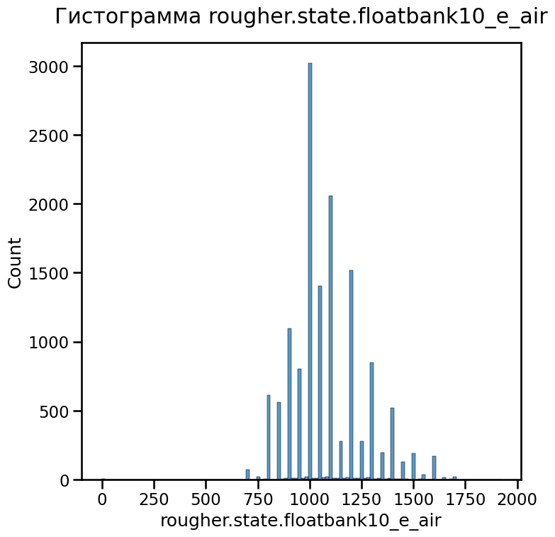

```python
sns.histplot(gi_train['rougher.state.floatbank10_e_air'])
plt.title('Гистограмма rougher.state.floatbank10_e_air');
```

```python
gi_train['rougher.state.floatbank10_e_air'].corr(gi_train['rougher.state.floatbank10_e_level'],
                                                 method='pearson', min_periods=None)
```

```
0.3879865778440805
```

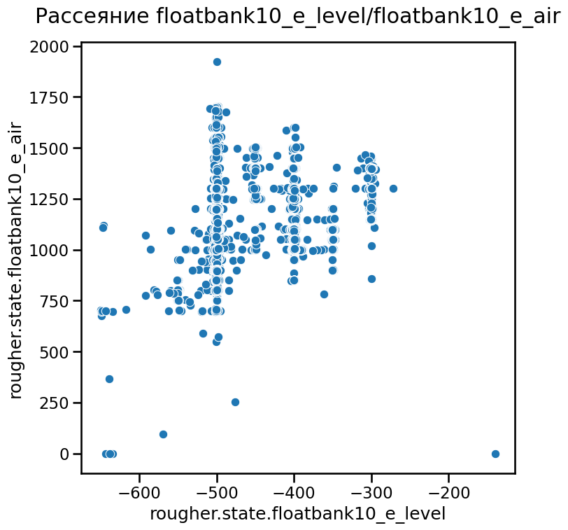

```python
sns.scatterplot(x=gi_train['rougher.state.floatbank10_e_level'],
                y=gi_train['rougher.state.floatbank10_e_air']);
plt.title('Рассеяние floatbank10_e_level/floatbank10_e_air');
```

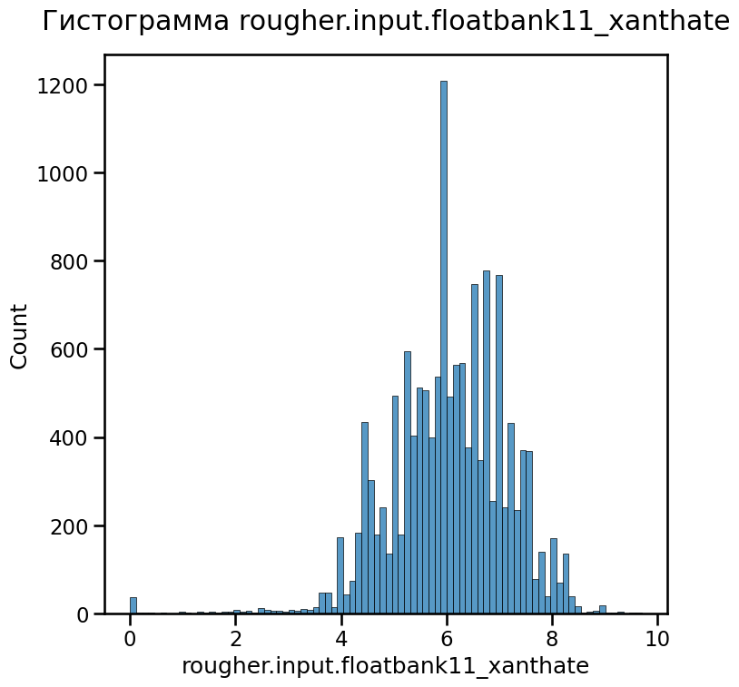

```python
sns.histplot(gi_train['rougher.input.floatbank11_xanthate']);
plt.title('Гистограмма rougher.input.floatbank11_xanthate');
```

```python
gi_train['rougher.input.floatbank11_sulfate'].corr(gi_train['rougher.input.floatbank11_xanthate'],
                                                 method='pearson', min_periods=None)
```

```
0.1471920982218306
```

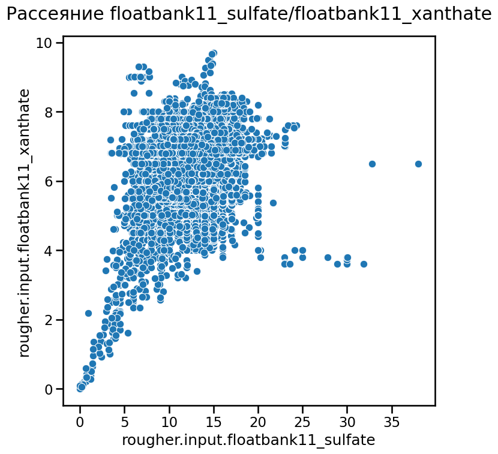

```python
sns.scatterplot(x=gi_train['rougher.input.floatbank11_sulfate'],
                y=gi_train['rougher.input.floatbank11_xanthate']);
plt.title('Рассеяние floatbank11_sulfate/floatbank11_xanthate');
```

```python
gi_train.dropna().shape[0]
```

```
13371
```

```python
(1 - gi_train.dropna().shape[0] / gi_train.shape[0]) * 100
```

```
8.285890664654637
```

```python
gi_train.dropna(inplace=True)
```

```python
gi_train.isnull().sum()
```

```
date                                          0
rougher.input.feed_au                         0
rougher.input.feed_ag                         0
rougher.input.feed_pb                         0
rougher.input.feed_sol                        0
rougher.input.feed_rate                       0
rougher.input.feed_size                       0
rougher.input.floatbank10_sulfate             0
rougher.input.floatbank10_xanthate            0
rougher.state.floatbank10_a_air               0
rougher.state.floatbank10_a_level             0
rougher.state.floatbank10_b_air               0
rougher.state.floatbank10_b_level             0
rougher.state.floatbank10_c_air               0
rougher.state.floatbank10_c_level             0
rougher.state.floatbank10_d_air               0
rougher.state.floatbank10_d_level             0
rougher.state.floatbank10_e_air               0
rougher.state.floatbank10_e_level             0
rougher.state.floatbank10_f_air               0
rougher.state.floatbank10_f_level             0
rougher.input.floatbank11_sulfate             0
rougher.input.floatbank11_xanthate            0
rougher.output.recovery                       0
primary_cleaner.input.sulfate                 0
primary_cleaner.input.depressant              0
primary_cleaner.input.feed_size               0
primary_cleaner.input.xanthate                0
primary_cleaner.state.floatbank8_a_air        0
primary_cleaner.state.floatbank8_a_level      0
primary_cleaner.state.floatbank8_b_air        0
primary_cleaner.state.floatbank8_b_level      0
primary_cleaner.state.floatbank8_c_air        0
primary_cleaner.state.floatbank8_c_level      0
primary_cleaner.state.floatbank8_d_air        0
primary_cleaner.state.floatbank8_d_level      0
secondary_cleaner.state.floatbank2_a_air      0
secondary_cleaner.state.floatbank2_a_level    0
secondary_cleaner.state.floatbank2_b_air      0
secondary_cleaner.state.floatbank2_b_level    0
secondary_cleaner.state.floatbank3_a_air      0
secondary_cleaner.state.floatbank3_a_level    0
secondary_cleaner.state.floatbank3_b_air      0
secondary_cleaner.state.floatbank3_b_level    0
secondary_cleaner.state.floatbank4_a_air      0
secondary_cleaner.state.floatbank4_a_level    0
secondary_cleaner.state.floatbank4_b_air      0
secondary_cleaner.state.floatbank4_b_level    0
secondary_cleaner.state.floatbank5_a_air      0
secondary_cleaner.state.floatbank5_a_level    0
secondary_cleaner.state.floatbank5_b_air      0
secondary_cleaner.state.floatbank5_b_level    0
secondary_cleaner.state.floatbank6_a_air      0
secondary_cleaner.state.floatbank6_a_level    0
final.output.recovery                         0
dtype: int64
```

```python
gi_test.shape[0]
```

```
4860
```

```python
gi_test.isnull().sum()
```

```
date                                            0
rougher.input.feed_au                           0
rougher.input.feed_ag                           0
rougher.input.feed_pb                          28
rougher.input.feed_sol                         22
rougher.input.feed_rate                         4
rougher.input.feed_size                        44
rougher.input.floatbank10_sulfate               3
rougher.input.floatbank10_xanthate              1
rougher.state.floatbank10_a_air                 1
rougher.state.floatbank10_a_level               1
rougher.state.floatbank10_b_air                 1
rougher.state.floatbank10_b_level               1
rougher.state.floatbank10_c_air                 1
rougher.state.floatbank10_c_level               1
rougher.state.floatbank10_d_air                 0
rougher.state.floatbank10_d_level               0
rougher.state.floatbank10_e_air                 7
rougher.state.floatbank10_e_level               0
rougher.state.floatbank10_f_air                 0
rougher.state.floatbank10_f_level               0
rougher.input.floatbank11_sulfate               8
rougher.input.floatbank11_xanthate             46
primary_cleaner.input.sulfate                   1
primary_cleaner.input.depressant                9
primary_cleaner.input.feed_size                 0
primary_cleaner.input.xanthate                 43
primary_cleaner.state.floatbank8_a_air          1
primary_cleaner.state.floatbank8_a_level        1
primary_cleaner.state.floatbank8_b_air          1
primary_cleaner.state.floatbank8_b_level        1
primary_cleaner.state.floatbank8_c_air          2
primary_cleaner.state.floatbank8_c_level        1
primary_cleaner.state.floatbank8_d_air          2
primary_cleaner.state.floatbank8_d_level        1
secondary_cleaner.state.floatbank2_a_air      126
secondary_cleaner.state.floatbank2_a_level      1
secondary_cleaner.state.floatbank2_b_air        1
secondary_cleaner.state.floatbank2_b_level      1
secondary_cleaner.state.floatbank3_a_air        1
secondary_cleaner.state.floatbank3_a_level      1
secondary_cleaner.state.floatbank3_b_air        1
secondary_cleaner.state.floatbank3_b_level      1
secondary_cleaner.state.floatbank4_a_air        1
secondary_cleaner.state.floatbank4_a_level      1
secondary_cleaner.state.floatbank4_b_air        1
secondary_cleaner.state.floatbank4_b_level      1
secondary_cleaner.state.floatbank5_a_air        1
secondary_cleaner.state.floatbank5_a_level      1
secondary_cleaner.state.floatbank5_b_air        1
secondary_cleaner.state.floatbank5_b_level      1
secondary_cleaner.state.floatbank6_a_air        1
secondary_cleaner.state.floatbank6_a_level      1
dtype: int64
```

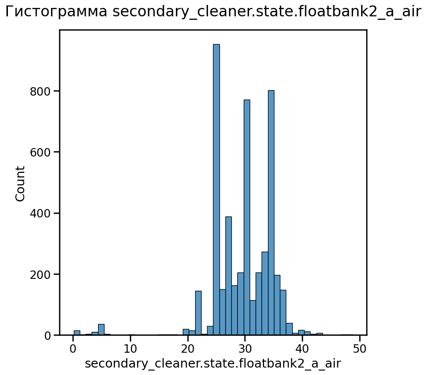

```python
sns.histplot(gi_test['secondary_cleaner.state.floatbank2_a_air']);
plt.title('Гистограмма secondary_cleaner.state.floatbank2_a_air');
```

```python
gi_train['secondary_cleaner.state.floatbank2_a_air'].corr(gi_train['secondary_cleaner.state.floatbank2_a_level'],
                                                 method='pearson', min_periods=None)
```

```
0.44033419451977573
```

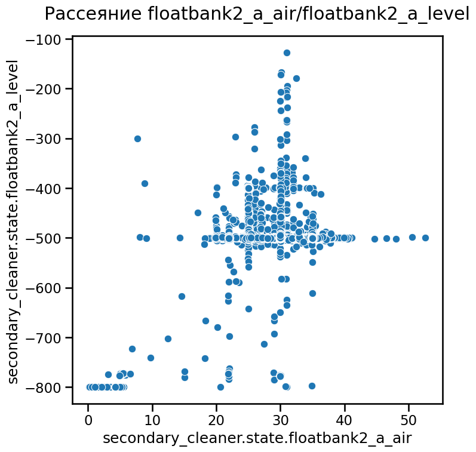

```python
sns.scatterplot(x=gi_train['secondary_cleaner.state.floatbank2_a_air'],
                y=gi_train['secondary_cleaner.state.floatbank2_a_level']);

plt.title('Рассеяние floatbank2_a_air/floatbank2_a_level');
```

```python
gi_test.dropna().shape[0]
```

```
4537
```

```python
(1 - gi_test.dropna().shape[0] / gi_test.shape[0]) * 100
```

```
6.646090534979421
```

```python
gi_test_old = gi_test.copy()
```

```python
gi_test.dropna(inplace=True)
```

```python
gi_test.isnull().sum()
```

```
date                                          0
rougher.input.feed_au                         0
rougher.input.feed_ag                         0
rougher.input.feed_pb                         0
rougher.input.feed_sol                        0
rougher.input.feed_rate                       0
rougher.input.feed_size                       0
rougher.input.floatbank10_sulfate             0
rougher.input.floatbank10_xanthate            0
rougher.state.floatbank10_a_air               0
rougher.state.floatbank10_a_level             0
rougher.state.floatbank10_b_air               0
rougher.state.floatbank10_b_level             0
rougher.state.floatbank10_c_air               0
rougher.state.floatbank10_c_level             0
rougher.state.floatbank10_d_air               0
rougher.state.floatbank10_d_level             0
rougher.state.floatbank10_e_air               0
rougher.state.floatbank10_e_level             0
rougher.state.floatbank10_f_air               0
rougher.state.floatbank10_f_level             0
rougher.input.floatbank11_sulfate             0
rougher.input.floatbank11_xanthate            0
primary_cleaner.input.sulfate                 0
primary_cleaner.input.depressant              0
primary_cleaner.input.feed_size               0
primary_cleaner.input.xanthate                0
primary_cleaner.state.floatbank8_a_air        0
primary_cleaner.state.floatbank8_a_level      0
primary_cleaner.state.floatbank8_b_air        0
primary_cleaner.state.floatbank8_b_level      0
primary_cleaner.state.floatbank8_c_air        0
primary_cleaner.state.floatbank8_c_level      0
primary_cleaner.state.floatbank8_d_air        0
primary_cleaner.state.floatbank8_d_level      0
secondary_cleaner.state.floatbank2_a_air      0
secondary_cleaner.state.floatbank2_a_level    0
secondary_cleaner.state.floatbank2_b_air      0
secondary_cleaner.state.floatbank2_b_level    0
secondary_cleaner.state.floatbank3_a_air      0
secondary_cleaner.state.floatbank3_a_level    0
secondary_cleaner.state.floatbank3_b_air      0
secondary_cleaner.state.floatbank3_b_level    0
secondary_cleaner.state.floatbank4_a_air      0
secondary_cleaner.state.floatbank4_a_level    0
secondary_cleaner.state.floatbank4_b_air      0
secondary_cleaner.state.floatbank4_b_level    0
secondary_cleaner.state.floatbank5_a_air      0
secondary_cleaner.state.floatbank5_a_level    0
secondary_cleaner.state.floatbank5_b_air      0
secondary_cleaner.state.floatbank5_b_level    0
secondary_cleaner.state.floatbank6_a_air      0
secondary_cleaner.state.floatbank6_a_level    0
dtype: int64
```

**Выводы**

Среди данных есть пропуски. При отбрасывании их теряется 8.28 процентов обучающей и 6.64 процента контрольной, это достаточно большое количество для беспокойства. Однако, данные сложные, признаки, для которых наиболее често встречаются пропуски, не имеют достаточно высокой корреляции или зависимости с наиболее близкими им по техническим условиям признакам. Таким образом восстановление может привести к большему искажению генеральной совокупности.

Отбросим пропуски, сохраним копию контрольной БД для дальнейшего анализа, чтобы проверить насколько отбрасывание повлияло на данные. Копия обучающей уже сохранена.

#### 1.4.2. Дубликаты

```python
gi_train.duplicated().sum()
```

```
0
```

```python
gi_test.duplicated().sum()
```

```
0
```

```python
gi_full.duplicated().sum()
```

```
0
```

**Выводы**

Полных дубликатов нет.

#### 1.4.3. Типы данных

```python
gi_full.dtypes.value_counts()
```

```
float64    86
object      1
dtype: int64
```

```python
gi_full.date
```

```
0        2016-01-15 00:00:00
1        2016-01-15 01:00:00
2        2016-01-15 02:00:00
3        2016-01-15 03:00:00
4        2016-01-15 04:00:00
                ...
19434    2018-08-18 06:59:59
19435    2018-08-18 07:59:59
19436    2018-08-18 08:59:59
19437    2018-08-18 09:59:59
19438    2018-08-18 10:59:59
Name: date, Length: 19439, dtype: object
```

```python
gi_train.date = pd.to_datetime(gi_train.date)
gi_test.date = pd.to_datetime(gi_test.date)
gi_full.date = pd.to_datetime(gi_full.date)
```

```python
gi_full.date
```

```
0       2016-01-15 00:00:00
1       2016-01-15 01:00:00
2       2016-01-15 02:00:00
3       2016-01-15 03:00:00
4       2016-01-15 04:00:00
                ...
19434   2018-08-18 06:59:59
19435   2018-08-18 07:59:59
19436   2018-08-18 08:59:59
19437   2018-08-18 09:59:59
19438   2018-08-18 10:59:59
Name: date, Length: 19439, dtype: datetime64[ns]
```

**Выводы**

Данные в целом представены действительными числами. Не вижу оснований изменять их тип данных. Столбец Дата - исключение, выступает во многом связным столбцом для баз данных, переведём в формат даты pandas для всех баз данных.

## 2. Анализ данных

2. Проанализируйте данные

### 2.1. Столбец Дат

```python
gi_full.date.duplicated().sum()
```

```
0
```

```python
(gi_full.date.min(), gi_full.date.max())
```

```
(Timestamp('2016-01-15 00:00:00'), Timestamp('2018-08-18 10:59:59'))
```

```python
(gi_train.date.min(), gi_train.date.max())
```

```
(Timestamp('2016-01-15 00:00:00'), Timestamp('2017-12-09 13:59:59'))
```

```python
(gi_test.date.min(), gi_test.date.max())
```

```
(Timestamp('2017-12-09 14:59:59'), Timestamp('2018-08-18 10:59:59'))
```

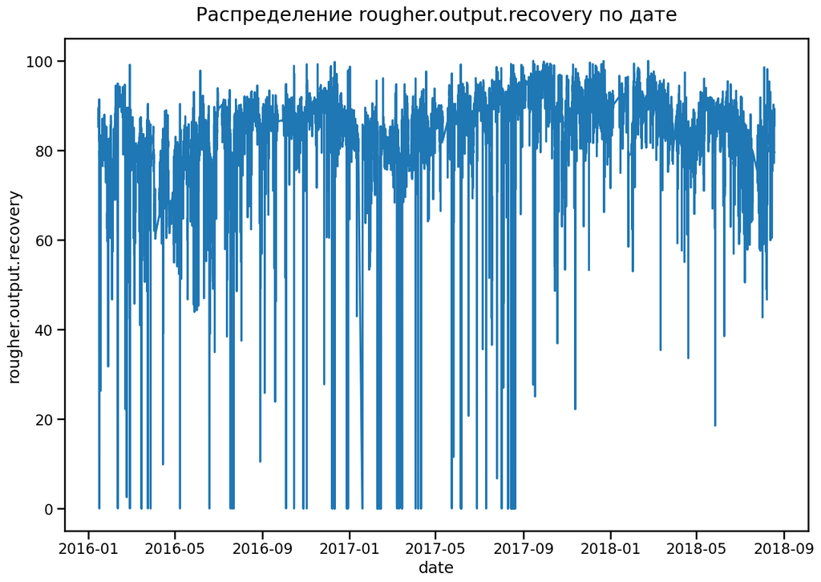

```python
sns.lineplot(data=gi_full, x='date', y='rougher.output.recovery').figure.set_size_inches(15,10);
plt.title('Распределение rougher.output.recovery по дате');
```

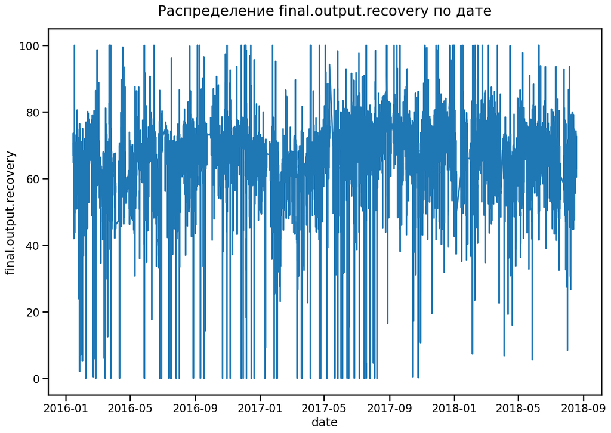

```python
sns.lineplot(data=gi_full, x='date', y='final.output.recovery').figure.set_size_inches(15,10);
plt.title('Распределение final.output.recovery по дате');
```

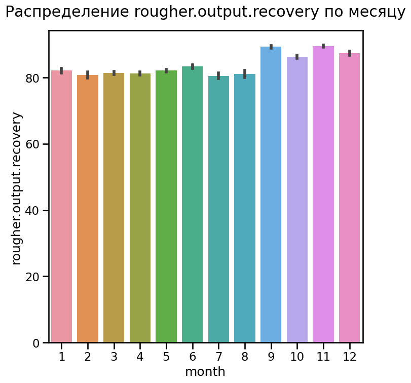

```python
sns.barplot(data=gi_full, x=gi_full.date.dt.month, y='rougher.output.recovery');
plt.xlabel('month');
plt.title('Распределение rougher.output.recovery по месяцу');
```

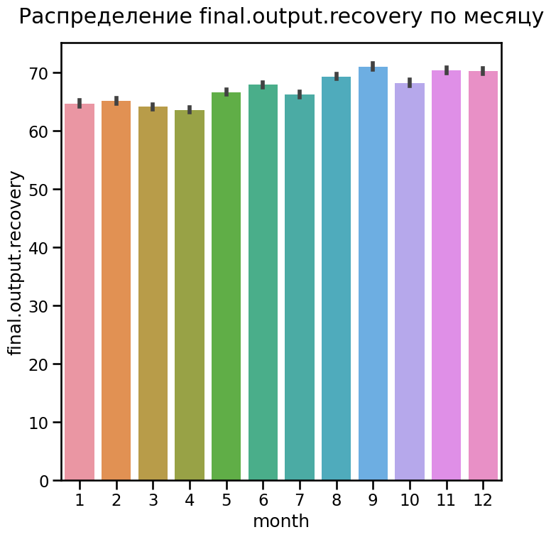

```python
sns.barplot(data=gi_full, x=gi_full.date.dt.month, y='final.output.recovery');
plt.xlabel('month');
plt.title('Распределение final.output.recovery по месяцу');
```

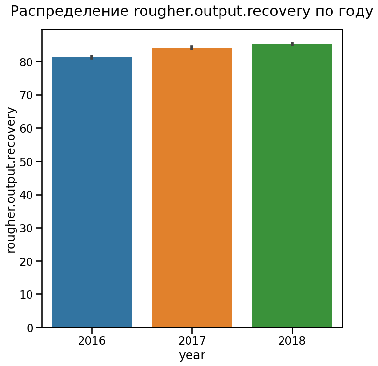

```python
sns.barplot(data=gi_full, x=gi_full.date.dt.year, y='rougher.output.recovery');
plt.xlabel('year');
plt.title('Распределение rougher.output.recovery по году');
```

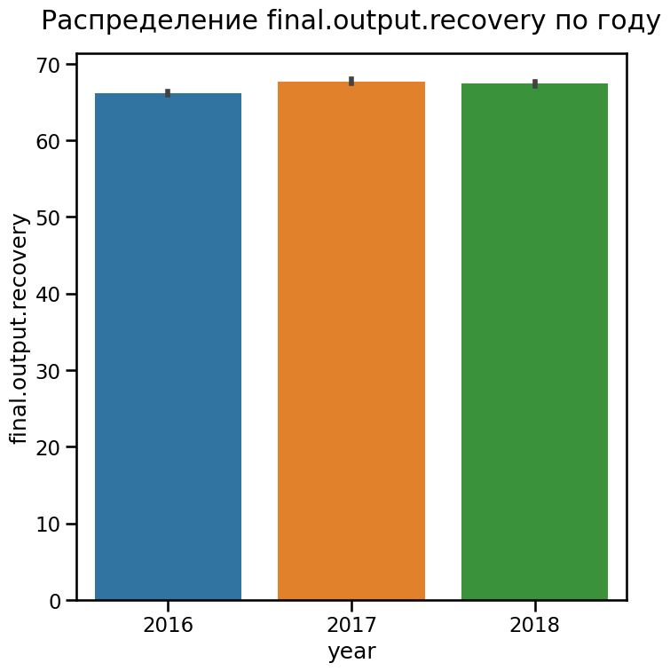

```python
sns.barplot(data=gi_full, x=gi_full.date.dt.year, y='final.output.recovery');
plt.xlabel('year');
plt.title('Распределение final.output.recovery по году');
```

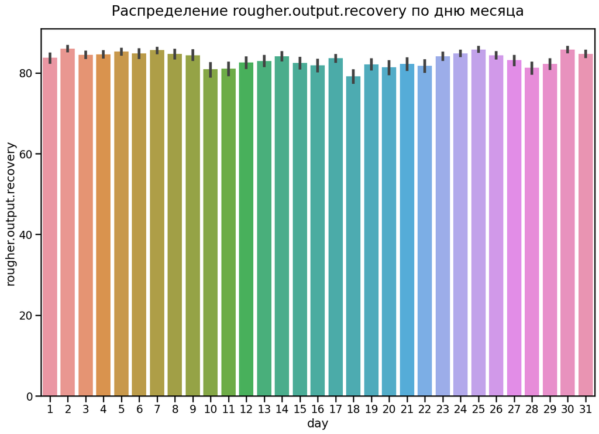

```python
sns.barplot(data=gi_full, x=gi_full.date.dt.day, y='rougher.output.recovery').figure.set_size_inches(15,10)
plt.xlabel('day');
plt.title('Распределение rougher.output.recovery по дню месяца');
```

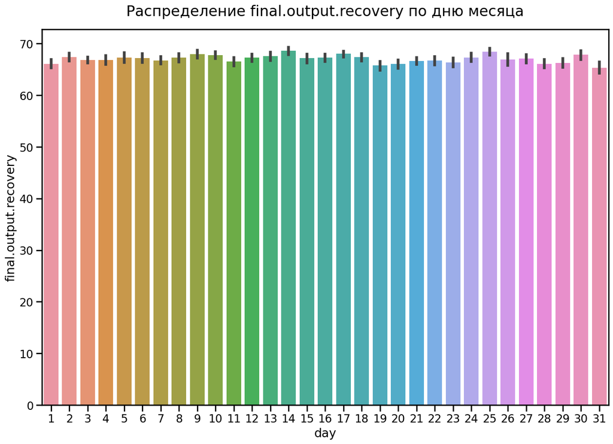

```python
sns.barplot(data=gi_full, x=gi_full.date.dt.day, y='final.output.recovery').figure.set_size_inches(15,10)
plt.xlabel('day');
plt.title('Распределение final.output.recovery по дню месяца');
```

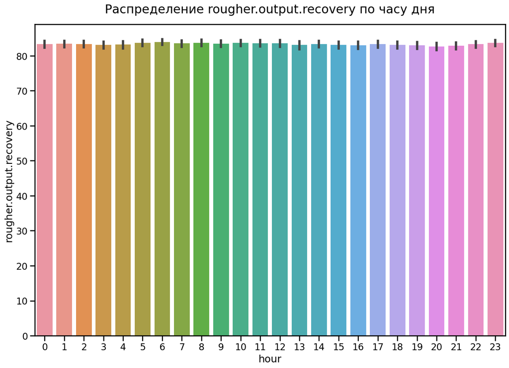

```python
sns.barplot(data=gi_full, x=gi_full.date.dt.hour , y='rougher.output.recovery').figure.set_size_inches(15,10)
plt.xlabel('hour');
plt.title('Распределение rougher.output.recovery по часу дня');
```

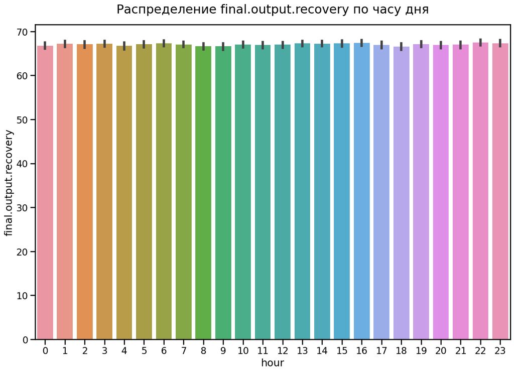

```python
sns.barplot(data=gi_full, x=gi_full.date.dt.hour, y='final.output.recovery').figure.set_size_inches(15,10)
plt.xlabel('hour');
plt.title('Распределение final.output.recovery по часу дня');
```

```python
gi_train.set_index('date', inplace=True)
gi_test.set_index('date', inplace=True)
gi_full.set_index('date', inplace=True)
```

**Выводы**

Данные в полной БД представлены на период с `2016-01-15 00:00:00` до `2018-08-18 10:59:59`. Разделение на выборки проходит по дате, с `2017-12-09 14:59:59` начинается контрольная выборка.

Столбец с датами имеет ряд особенностей в рамках данного проекта, в частности:

- Содержит только уникальные значения
- Не имеет явной информативной пользы для модели МО, как показывают графики ни дат в целом, ни год, ни месяца или года, ни даже день или час не оказывают значительного влияния на целевые признаки. Хотя стоит заметить что ЦП чуть более стабильны в последней трети периода времени, который представлен в данных, т.е. фактически в контрольной выборке.
- Даже может создать ложные закономерности, потому что вариация изо дня в день зависит от слишком большого количества условий чтобы полагаться на неё в качестве признака
- Является наиболее однозначным идентификатором записей среди признаков с человеческой точки зрения.

Таким образом он отлично подходит как индекс для наших баз данных, тем самым мы исключаем его из поля зрения модели, сохраняя при этом его пользу как уникального идентификатора.

### 2.2. Концентрация металлов (Au, Ag, Pb) на различных этапах

2.1. Посмотрите, как меняется концентрация металлов (Au, Ag, Pb) на различных этапах: в сырье, в черновом концентрате, в концентрате после первой очистки и в финальном концентрате. Какие особенности имеют распределения? Опишите выводы.

```python
def metal_columns_fun(element):
    metal_columns = gi_full.columns[
    gi_full.columns.str.contains(element) &
    ~gi_full.columns.str.contains('calculation') &
    ~gi_full.columns.str.contains('tail')]
    return gi_full.loc[:, metal_columns]
```

```python
metals_concentration_medians = pd.DataFrame()
for metal, element in zip(['gold', 'silver', 'lead'], ['au', 'ag', 'pb']):
    metal_columns = metal_columns_fun(element)
    concentration_medians = metal_columns.median().reset_index(drop=True)
    metals_concentration_medians[metal] = concentration_medians
metals_concentration_medians.index=['input', 'rough', 'first', 'final']
metals_concentration_medians
```

|  | gold | silver | lead |
| --- | --- | --- | --- |
| input | 8.125839 | 8.593574 | 3.534895 |
| rough | 20.280214 | 12.098115 | 7.742580 |
| first | 32.841295 | 8.507298 | 10.152433 |
| final | 45.011244 | 5.066094 | 10.102433 |

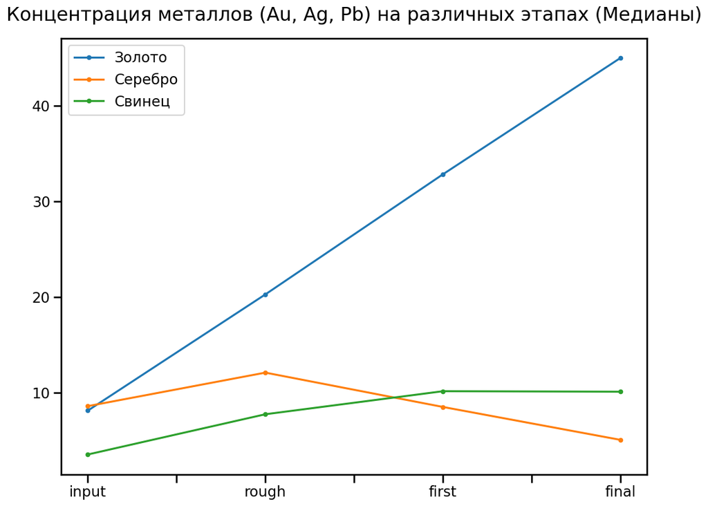

```python
metals_concentration_medians.plot(figsize=(12,9), style='.-');
plt.title('Концентрация металлов (Au, Ag, Pb) на различных этапах (Медианы)')
plt.legend(['Золото', 'Серебро', 'Свинец']);
```

```python
input_feed_metals = contains_extractor(gi_full, 'input.feed').iloc[:, :3]
input_feed_metals
```

| date | rougher.input.feed_au | rougher.input.feed_ag | rougher.input.feed_pb |
| --- | --- | --- | --- |
| 2016-01-15 00:00:00 | 6.486150 | 6.100378 | 2.284912 |
| 2016-01-15 01:00:00 | 6.478583 | 6.161113 | 2.266033 |
| 2016-01-15 02:00:00 | 6.362222 | 6.116455 | 2.159622 |
| 2016-01-15 03:00:00 | 6.118189 | 6.043309 | 2.037807 |
| 2016-01-15 04:00:00 | 5.663707 | 6.060915 | 1.786875 |
| ... | ... | ... | ... |
| 2018-08-18 06:59:59 | 6.620245 | 5.992592 | 2.589242 |
| 2018-08-18 07:59:59 | 6.741324 | 6.158617 | 2.647185 |
| 2018-08-18 08:59:59 | 6.627458 | 6.015149 | 2.466127 |
| 2018-08-18 09:59:59 | 6.702243 | 6.097592 | 2.278955 |
| 2018-08-18 10:59:59 | 6.633002 | 5.908793 | 2.440899 |

19439 rows × 3 columns

```python
metals_stages_list = ['rougher.input.feed', 'rougher.output.concentrate',
 'primary_cleaner.output.concentrate', 'final.output.concentrate']
metals_stages_list_ru = ['Сырьё', 'Флотация', 'Первичная Очистка', 'Финальный Результат']
```

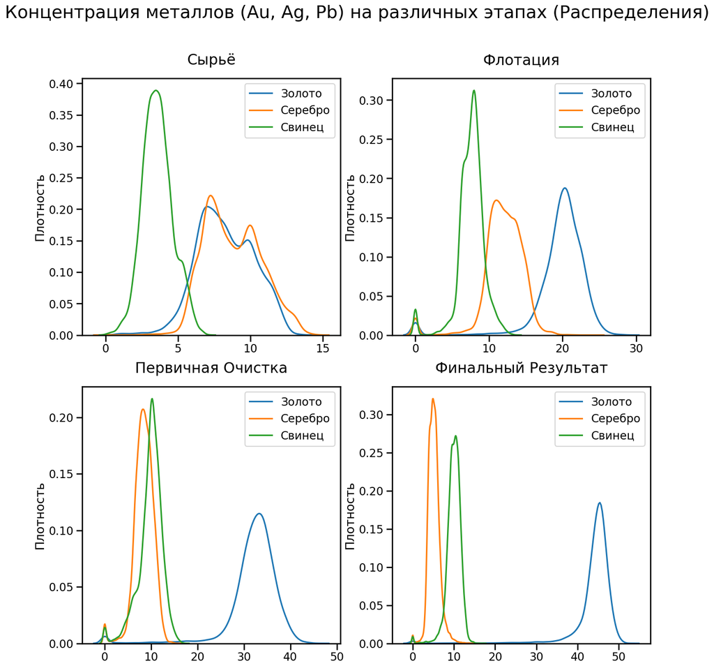

```python
f, axs = plt.subplots(2, 2, figsize=(15,15))
plt.suptitle('Концентрация металлов (Au, Ag, Pb) на различных этапах (Распределения)', size='x-large')
for stage, stage_ru, __ in zip(metals_stages_list, metals_stages_list_ru, range(4)):
    metals = contains_extractor(gi_full, stage).iloc[:, :3]
    for _ in range(3):
        sns.kdeplot(metals.iloc[:, _], ax=axs.flatten()[__])
    axs.flatten()[__].set_title(stage_ru)
    axs.flatten()[__].set_ylabel('Плотность')
    axs.flatten()[__].set_xlabel('')
    axs.flatten()[__].legend(['Золото', 'Серебро', 'Свинец'])
```

```python
(
    contains_extractor(gi_full, 'concentrate')
    [(contains_extractor(gi_full, 'concentrate') == 0).apply(any, axis='columns')].head(10)
    .join(contains_extractor(gi_full, 'recovery'))
)
```

| date | rougher.calculation.sulfate_to_au_concentrate | rougher.output.concentrate_au | rougher.output.concentrate_ag | rougher.output.concentrate_pb | rougher.output.concentrate_sol | primary_cleaner.output.concentrate_au | primary_cleaner.output.concentrate_ag | primary_cleaner.output.concentrate_pb | primary_cleaner.output.concentrate_sol | final.output.concentrate_au | final.output.concentrate_ag | final.output.concentrate_pb | final.output.concentrate_sol | rougher.output.recovery | final.output.recovery |
| --- | --- | --- | --- | --- | --- | --- | --- | --- | --- | --- | --- | --- | --- | --- | --- |
| 2016-01-15 14:00:00 | 41959.818540 | 18.511902 | 10.788951 | 7.537074 | 26.092838 | 0.000000 | 0.000000 | 0.000000 | 0.000000 | 42.509402 | 5.658943 | 10.436002 | 5.942418 | 86.241795 | 70.348300 |
| 2016-01-15 17:00:00 | 42082.414968 | 18.089134 | 10.958096 | 7.267608 | 25.911055 | 0.000000 | 0.000000 | 0.000000 | 0.000000 | 41.406172 | 6.118749 | 10.483007 | 6.546983 | 88.132239 | 69.823900 |
| 2016-01-16 01:00:00 | 41974.790294 | 17.583602 | 11.574823 | 7.384216 | 25.740506 | 0.000000 | 0.000000 | 0.000000 | 0.000000 | 44.059908 | 5.322681 | 9.577672 | 4.805490 | 88.066903 | 69.193840 |
| 2016-01-16 12:00:00 | 41359.061159 | 0.000000 | 0.000000 | 0.000000 | 0.000000 | 37.633572 | 8.513177 | 9.724797 | 19.120964 | 46.614456 | 4.566664 | 10.406178 | 4.588698 | 0.000000 | 68.403877 |
| 2016-01-16 13:00:00 | 41274.202372 | 0.000000 | 0.000000 | 0.000000 | 0.000000 | 37.718947 | 8.466262 | 9.780929 | 19.220963 | 46.250638 | 4.577832 | 10.691605 | 5.274175 | 0.000000 | 70.675633 |
| 2016-01-16 14:00:00 | 35990.036451 | 0.000000 | 0.000000 | 0.000000 | 0.000000 | 38.624404 | 8.092185 | 9.719728 | 19.077471 | 46.663335 | 4.591462 | 10.628846 | 5.688961 | 0.000000 | 55.088448 |
| 2016-01-16 15:00:00 | 33615.706291 | 0.000000 | 0.000000 | 0.000000 | 0.000000 | 40.086360 | 7.680496 | 9.038210 | 18.686350 | 44.015642 | 5.296830 | 10.597469 | NaN | 0.000000 | 41.962008 |
| 2016-01-16 16:00:00 | 92479.188718 | 0.000000 | 0.000000 | 0.000000 | 0.000000 | 33.895014 | 10.545583 | 8.209346 | 19.187922 | 40.715973 | 8.162896 | 8.877528 | NaN | 0.000000 | 49.884856 |
| 2016-01-16 17:00:00 | 46240.429927 | 0.000000 | 0.000000 | 0.000000 | 0.000000 | 34.822988 | 9.877097 | 8.932357 | 19.111308 | 45.267942 | 5.759800 | 9.537415 | 3.997737 | 0.000000 | 68.638723 |
| 2016-01-16 18:00:00 | 39633.731100 | 0.000000 | 0.000000 | 0.000000 | 0.000000 | 32.413685 | 10.806964 | 9.382084 | 19.502217 | 43.237493 | 5.807253 | 10.439505 | 6.512951 | 0.000000 | 72.136712 |

```python
(
    contains_extractor(gi_full, 'rougher')
    [(contains_extractor(gi_full, 'recovery') == 0).apply(any, axis='columns')].head(10)
    .join(contains_extractor(gi_full, 'final.output.recovery'))

)
```

| date | rougher.input.feed_au | rougher.input.feed_ag | rougher.input.feed_pb | rougher.input.feed_sol | rougher.input.feed_rate | rougher.input.feed_size | rougher.input.floatbank10_sulfate | rougher.input.floatbank10_xanthate | rougher.state.floatbank10_a_air | rougher.state.floatbank10_a_level | ... | rougher.output.concentrate_au | rougher.output.concentrate_ag | rougher.output.concentrate_pb | rougher.output.concentrate_sol | rougher.output.recovery | rougher.output.tail_au | rougher.output.tail_ag | rougher.output.tail_pb | rougher.output.tail_sol | final.output.recovery |
| --- | --- | --- | --- | --- | --- | --- | --- | --- | --- | --- | --- | --- | --- | --- | --- | --- | --- | --- | --- | --- | --- |
| 2016-01-16 12:00:00 | 7.114065 | 7.521974 | 2.811569 | 41.154430 | 581.605260 | 65.620714 | 13.322740 | 7.504592 | 999.026619 | -499.850895 | ... | 0.000000 | 0.000000 | 0.000000 | 0.000000 | 0.000000 | 1.939811 | 4.784398 | 0.818965 | 20.046797 | 68.403877 |
| 2016-01-16 13:00:00 | 7.651522 | 7.313187 | 2.973841 | 41.983063 | 562.972841 | 66.014780 | 14.433889 | 7.583598 | 999.846655 | -500.082738 | ... | 0.000000 | 0.000000 | 0.000000 | 0.000000 | 0.000000 | 2.087628 | 4.955785 | 0.891051 | 19.633741 | 70.675633 |
| 2016-01-16 14:00:00 | 5.587750 | 7.934791 | 1.763437 | NaN | 229.379445 | 40.601032 | 10.865871 | 5.648950 | 1003.354806 | -501.078303 | ... | 0.000000 | 0.000000 | 0.000000 | 0.000000 | 0.000000 | 2.126460 | 4.990718 | 0.901107 | 19.096033 | 55.088448 |
| 2016-01-16 15:00:00 | 4.752992 | 7.756881 | 1.025762 | 11.816724 | 228.510521 | 41.248945 | 5.908582 | 5.048482 | 998.548594 | -500.170221 | ... | 0.000000 | 0.000000 | 0.000000 | 0.000000 | 0.000000 | 1.938869 | 4.711415 | 0.636352 | 12.720009 | 41.962008 |
| 2016-01-16 16:00:00 | 5.122801 | 5.393466 | 1.824835 | 28.380274 | 550.606559 | 45.329106 | 10.060214 | 7.758600 | 1000.013401 | -499.520359 | ... | 0.000000 | 0.000000 | 0.000000 | 0.000000 | 0.000000 | 2.050901 | 4.933318 | 0.781390 | 16.769068 | 49.884856 |
| 2016-01-16 17:00:00 | 7.039270 | 7.835670 | 2.770323 | 38.010139 | 565.344417 | 45.331628 | 12.785794 | 7.797513 | 1000.758702 | -500.025854 | ... | 0.000000 | 0.000000 | 0.000000 | 0.000000 | 0.000000 | 2.047653 | 5.005911 | 0.815523 | 19.102734 | 68.638723 |
| 2016-01-16 18:00:00 | 7.321526 | 8.027547 | 3.073579 | 39.417952 | 588.801743 | 45.334149 | 14.027409 | 7.802530 | 1000.030945 | -499.720448 | ... | 0.000000 | 0.000000 | 0.000000 | 0.000000 | 0.000000 | 2.011165 | 4.922270 | 0.827965 | 19.081450 | 72.136712 |
| 2016-02-08 00:00:00 | 5.598971 | 7.407737 | 1.934178 | 31.762853 | 500.087438 | 51.965198 | 10.251319 | 6.620908 | 999.884600 | -499.972731 | ... | 15.935190 | 11.803589 | 7.143475 | 21.692525 | 68.960993 | 2.293607 | 5.114923 | 0.925673 | 20.699912 | 0.000000 |
| 2016-02-11 12:00:00 | 11.433690 | 13.850236 | 5.503190 | 34.949583 | 400.202635 | 48.554205 | 14.468858 | 9.517497 | 997.783939 | -499.814517 | ... | 0.000000 | 0.000000 | 0.000000 | 0.000000 | 0.000000 | 1.445896 | 5.307234 | 0.346602 | 13.587201 | 80.041038 |
| 2016-02-26 17:00:00 | 7.786147 | 8.098125 | 2.588661 | 34.896012 | 502.314489 | 49.985298 | 8.842907 | 7.265263 | 1000.621368 | -499.594073 | ... | 18.682162 | 10.640168 | 7.565854 | 24.793448 | 82.787322 | 2.046213 | 6.102604 | 0.788412 | 21.096415 | 0.000000 |

10 rows × 36 columns

**Выводы**

Медианная концентрация золота растёт на каждом этапе, оправдывая метод производства. Содержание свинца растёт, но не сильно. Содержание серебра растёт во время флотации, и потом падает, что говорит нам о том, что производственный процесс подходит исключительно для извлечения золота.

Имеется странная аномалия в точке 0 начиная с флотации. возможно имеет место ошибка переноса данных, или какая-то техническая проблема, например датчиков. В ряде случаев это приводит к тому, что один из ЦП равен 0, рассмотрим распределение ЦП чтобы ознакомится с проблемой подробнее.

### 2.3. Распределение целевых признаков `recovery`

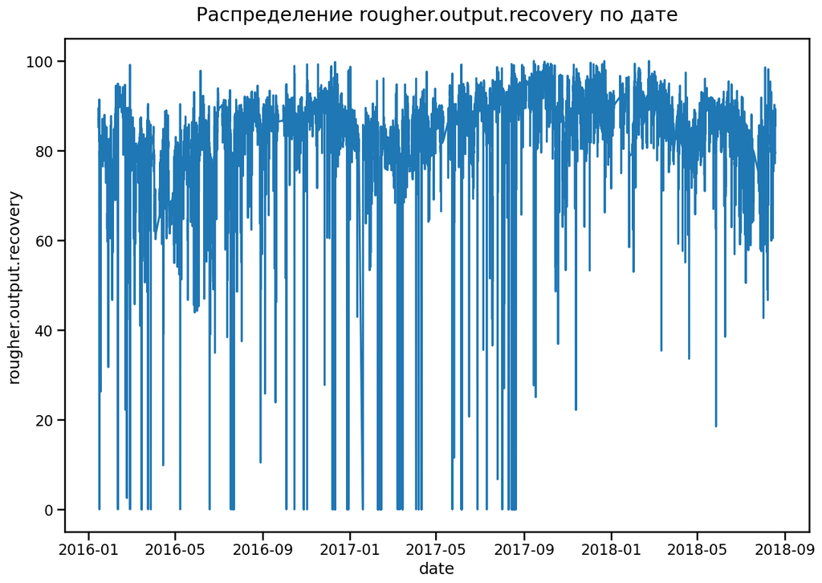

```python
sns.lineplot(data=gi_full, x='date', y='rougher.output.recovery').figure.set_size_inches(15,10);
plt.title('Распределение rougher.output.recovery по дате');
```

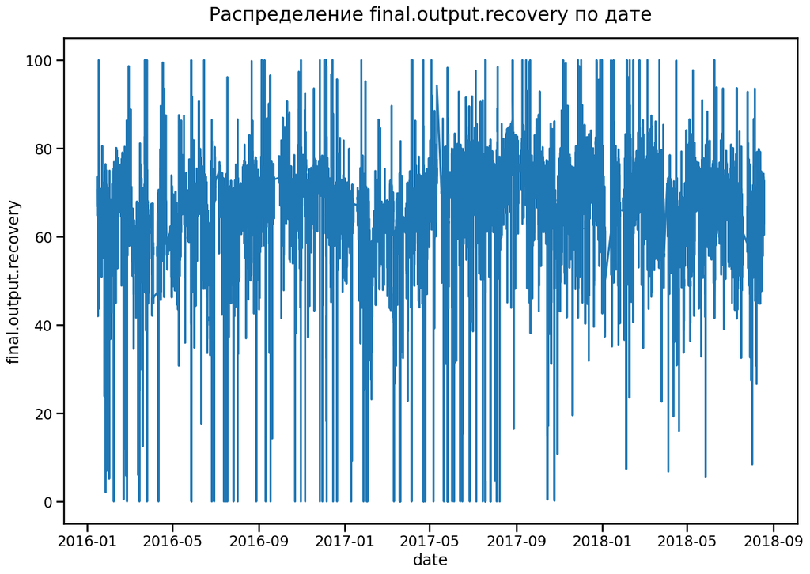

```python
sns.lineplot(data=gi_full, x='date', y='final.output.recovery').figure.set_size_inches(15,10);
plt.title('Распределение final.output.recovery по дате');
```

```python
gi_test = gi_test.join(contains_extractor(gi_full, 'recovery'))
```

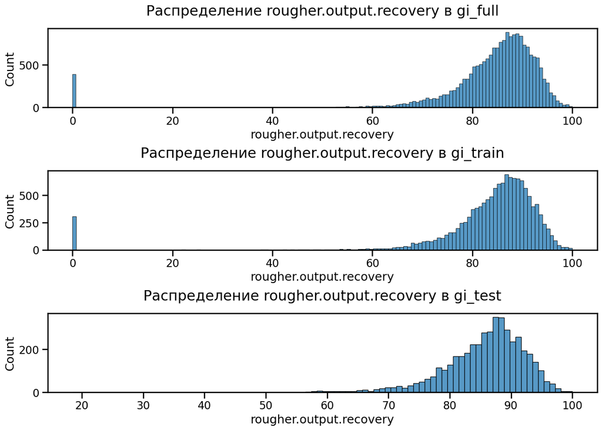

```python
samples_names = ['gi_full', 'gi_train', 'gi_test']
fig, axs = plt.subplots(3, figsize=(15,10))
plt.subplots_adjust(hspace=0.8)
for sample, name, _ in zip([gi_full, gi_train, gi_test], samples_names, range(3)):
    sns.histplot(data=sample, x='rougher.output.recovery', ax=axs[_])
    axs[_].set_title(f'Распределение rougher.output.recovery в {name}')
```

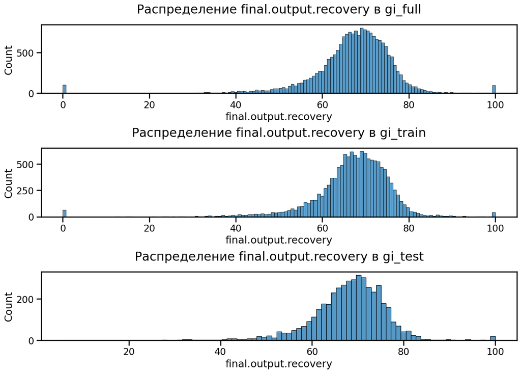

```python
fig, axs = plt.subplots(3, figsize=(15,10))
plt.subplots_adjust(hspace=0.8)
for sample, name, _ in zip([gi_full, gi_train, gi_test], samples_names, range(3)):
    sns.histplot(data=sample, x='final.output.recovery', ax=axs[_])
    axs[_].set_title(f'Распределение final.output.recovery в {name}')
```

[figure not shown]

```python
sns.histplot(gi_full[gi_full['final.output.recovery'] == 100]['rougher.output.recovery']);
plt.title('Гистограмма final.output.recovery для аномалий final.output.recovery == 100');
```

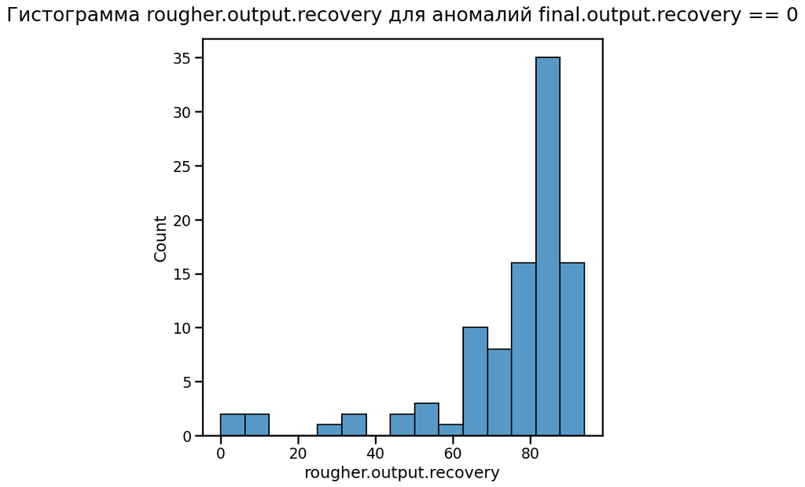

```python
sns.histplot(gi_full[gi_full['final.output.recovery'] == 0]['rougher.output.recovery']);
plt.title('Гистограмма rougher.output.recovery для аномалий final.output.recovery == 0');
```

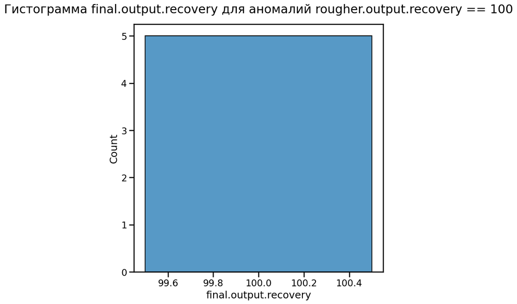

```python
sns.histplot(gi_full[gi_full['rougher.output.recovery'] == 100]['final.output.recovery']);
plt.title('Гистограмма final.output.recovery для аномалий rougher.output.recovery == 100');
```

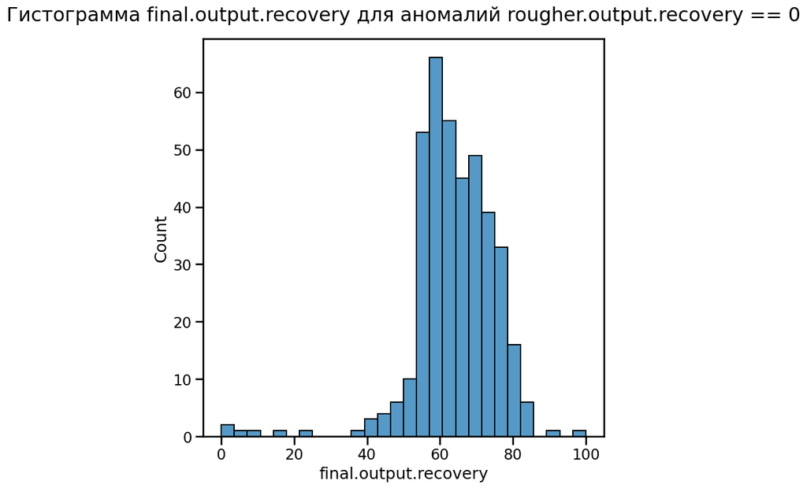

```python
sns.histplot(gi_full[gi_full['rougher.output.recovery'] == 0]['final.output.recovery']);
plt.title('Гистограмма final.output.recovery для аномалий rougher.output.recovery == 0');
```

```python
gi_train[(gi_train['final.output.recovery'] == 0) & (gi_train['rougher.output.recovery'] == 0)].shape[0]
```

```
1
```

```python
gi_test[(gi_test['final.output.recovery'] == 0) & (gi_test['rougher.output.recovery'] == 0)].shape[0]
```

```
0
```

```python
gi_train = gi_train.drop(gi_train[(gi_train['final.output.recovery'] == 0) & (gi_train['rougher.output.recovery'] == 0)].index)
```

```python
gi_train[gi_train['final.output.recovery'] == 0].shape[0]
```

```
63
```

```python
gi_test[gi_test['final.output.recovery'] == 0].shape[0]
```

```
0
```

```python
gi_train = gi_train.drop(gi_train[gi_train['final.output.recovery'] == 0].index)
```

```python
gi_train[gi_train['final.output.recovery'] == 100].shape[0]
```

```
35
```

```python
gi_test[gi_test['final.output.recovery'] == 100].shape[0]
```

```
17
```

```python
gi_train = gi_train.drop(gi_train[gi_train['final.output.recovery'] == 100].index)
```

```python
gi_test = gi_test.drop(gi_test[gi_test['final.output.recovery'] == 100].index)
```

```python
gi_train[gi_train['rougher.output.recovery'] == 0].shape[0]
```

```
305
```

```python
gi_test[gi_test['rougher.output.recovery'] == 0].shape[0]
```

```
0
```

```python
gi_train['rougher.output.recovery'] = (
    gi_train['rougher.output.recovery'].where(gi_train['rougher.output.recovery'] != 0, np.nan)
)
```

```python
gi_train['rougher.output.recovery'].isna().sum()
```

```
305
```

```python
gi_train[gi_train['rougher.output.recovery'] == 100].shape[0]
```

```
0
```

```python
gi_test[gi_test['rougher.output.recovery'] == 100].shape[0]
```

```
0
```

```python
cols_to_use = gi_full.columns.difference(gi_train.columns, sort=False)
train_concentrate =(
    contains_extractor(gi_train.dropna().join(gi_full[cols_to_use]), 'rougher.input.feed')
    .join(contains_extractor(gi_full, 'output.concentrate'))
)
test_concentrate =(
    contains_extractor(gi_test.dropna().join(gi_full[cols_to_use]), 'rougher.input.feed')
    .join(contains_extractor(gi_full, 'output.concentrate'))
)
```

```python
metals_stages_list = ['rougher.input.feed', 'rougher.output.concentrate',
 'primary_cleaner.output.concentrate', 'final.output.concentrate']
metals_stages_list_ru = ['Сырьё', 'Флотация', 'Первичная Очистка', 'Финальный Результат']
```

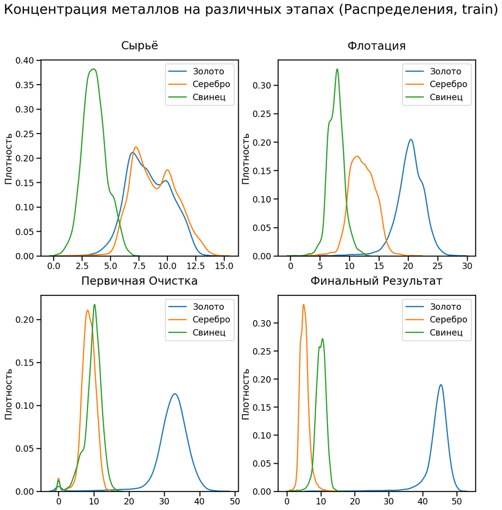

```python
f, axs = plt.subplots(2, 2, figsize=(15,15))
plt.suptitle('Концентрация металлов на различных этапах (Распределения, train)', size='x-large')
for stage, stage_ru, __ in zip(metals_stages_list, metals_stages_list_ru, range(4)):
    metals = contains_extractor(train_concentrate, stage).iloc[:, :3]
    for _ in range(3):
        sns.kdeplot(metals.iloc[:, _], ax=axs.flatten()[__])
    axs.flatten()[__].set_title(stage_ru)
    axs.flatten()[__].set_ylabel('Плотность')
    axs.flatten()[__].set_xlabel('')
    axs.flatten()[__].legend(['Золото', 'Серебро', 'Свинец'])
```

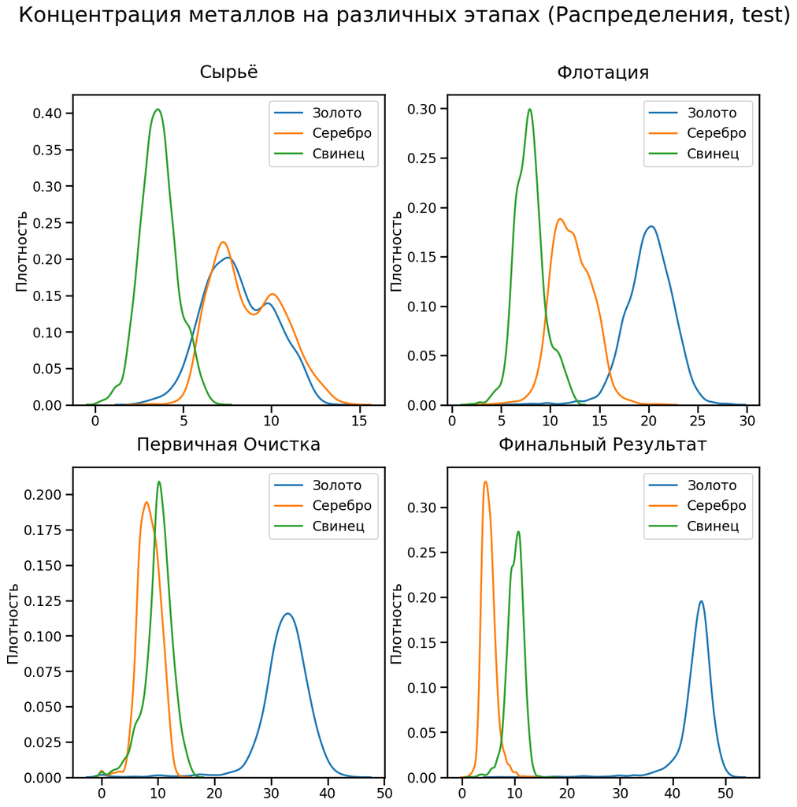

```python
f, axs = plt.subplots(2, 2, figsize=(15,15))
plt.suptitle('Концентрация металлов на различных этапах (Распределения, test)', size='x-large')
for stage, stage_ru, __ in zip(metals_stages_list, metals_stages_list_ru, range(4)):
    metals = contains_extractor(test_concentrate, stage).iloc[:, :3]
    for _ in range(3):
        sns.kdeplot(metals.iloc[:, _], ax=axs.flatten()[__])
    axs.flatten()[__].set_title(stage_ru)
    axs.flatten()[__].set_ylabel('Плотность')
    axs.flatten()[__].set_xlabel('')
    axs.flatten()[__].legend(['Золото', 'Серебро', 'Свинец'])
```

```python
(contains_extractor(train_concentrate, 'concentrate') == 0).apply(sum, axis='rows')
```

```
rougher.output.concentrate_au              0
rougher.output.concentrate_ag              0
rougher.output.concentrate_pb              0
rougher.output.concentrate_sol             0
primary_cleaner.output.concentrate_au     78
primary_cleaner.output.concentrate_ag     78
primary_cleaner.output.concentrate_pb     78
primary_cleaner.output.concentrate_sol    78
final.output.concentrate_au                0
final.output.concentrate_ag                0
final.output.concentrate_pb                0
final.output.concentrate_sol               0
dtype: int64
```

```python
(contains_extractor(test_concentrate, 'concentrate') == 0).apply(sum, axis='rows')
```

```
rougher.output.concentrate_au             0
rougher.output.concentrate_ag             0
rougher.output.concentrate_pb             0
rougher.output.concentrate_sol            0
primary_cleaner.output.concentrate_au     0
primary_cleaner.output.concentrate_ag     0
primary_cleaner.output.concentrate_pb     0
primary_cleaner.output.concentrate_sol    0
final.output.concentrate_au               0
final.output.concentrate_ag               0
final.output.concentrate_pb               0
final.output.concentrate_sol              0
dtype: int64
```

**Выводы**

В ходе анализа обнаружен ряд аномалий в целевых признаках. Большинство аномалий находится в обучающей выборке, о чём также говорит распределений ЦП по дате, т.к. выборки разбиты по дате.

Для ряда записей обучающей выборки `rougher.output.recovery` и `final.output.recovery` равны нулю. Скорее всего это связано с отсутствием данных о содержании золота в концентрате. Для `final.output.recovery` равных нулю также наблюдается распределение `rougher.output.recovery` сильно отличное от распределения в генеральной совокупности, отбросим их. В обратном случае искажение не наблюдается, заменим их пропусками и обработаем отдельно когда будем разделять данные на выборки для разных ЦП.

Для ряда записей обеих выборок `final.output.recovery` равны сотне. Это также скорее всего связано с отсутствием данных о содержании золота в концентрате. Имеет место явное искажение распределения `rougher.output.recovery` для обоих случаев, нельзя с уверенностью заявить чем оно вызвано, однако ввиду аномальных значений, отбросим их.

В генеральной совокупности также есть несколько записей где `rougher.output.recovery` равны сотне, однако на момент проверки в обучающей и тестовой выборке их нет, они были отброшены в процессе переработки.

В результате действий также удалось устранить все строки, где нулевые значения содержания элементов в концентрате влияли бы на ЦП. Так как сами данные о содержании элементов не передаются модели, сохранение строк где нули в результатах первичной очистки не скажется на качестве модели.

### 2.4. Распределения размеров гранул исходного сырья на обучающей и тестовой выборках

2.2. Сравните распределения размеров гранул исходного сырья на обучающей и тестовой выборках. Если распределения сильно отличаются друг от друга, оценка модели будет неправильной.

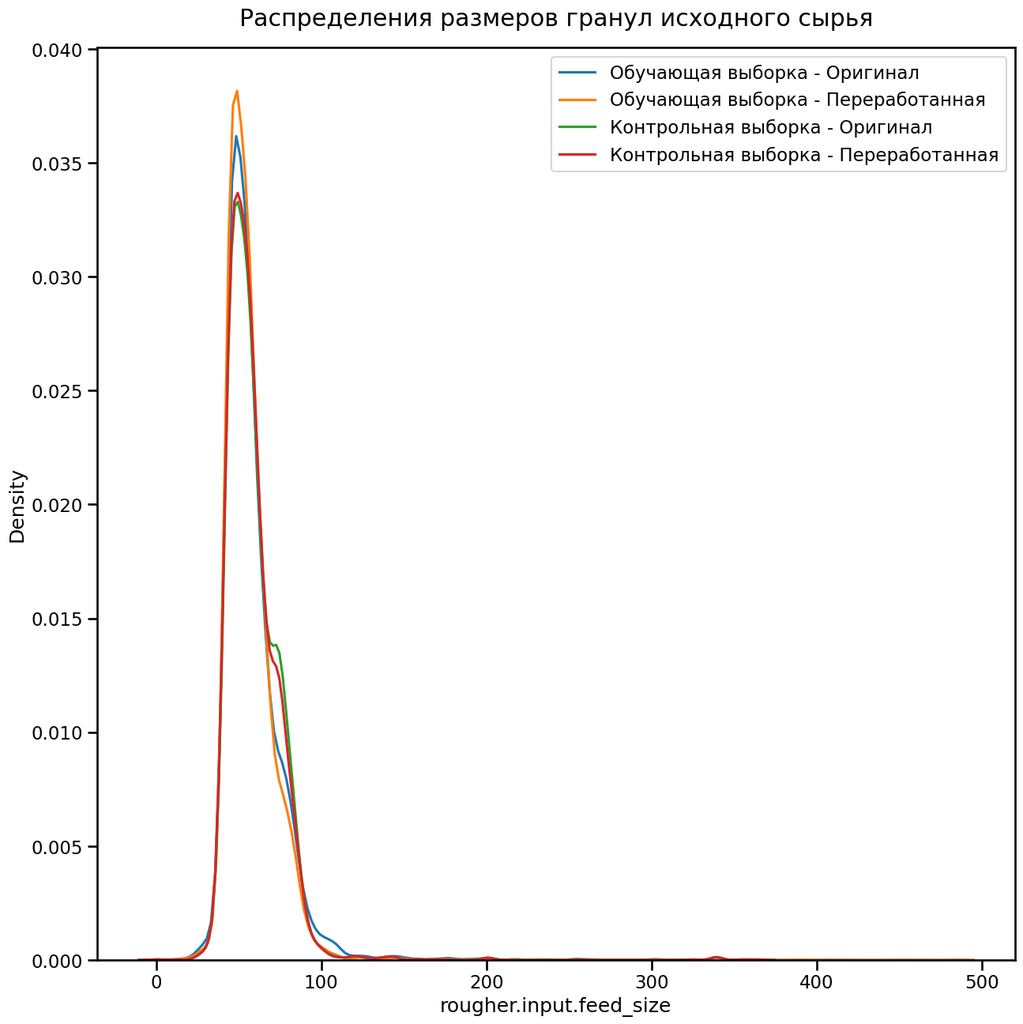

```python
plt.figure(figsize=(15,15))
sns.kdeplot(gi_train_old['rougher.input.feed_size'])
sns.kdeplot(gi_train['rougher.input.feed_size'])
sns.kdeplot(gi_test_old['rougher.input.feed_size'])
sns.kdeplot(gi_test['rougher.input.feed_size'])
plt.legend(['Обучающая выборка - Оригинал', 'Обучающая выборка - Переработанная','Контрольная выборка - Оригинал',
            'Контрольная выборка - Переработанная'])
plt.title('Распределения размеров гранул исходного сырья');
```

```python
gi_train['rougher.input.feed_size'].describe()
```

```
count    13272.000000
mean        57.297057
std         20.347147
min          0.049194
25%         46.942304
50%         53.716578
75%         62.653939
max        484.967466
Name: rougher.input.feed_size, dtype: float64
```

```python
gi_test['rougher.input.feed_size'].describe()
```

```
count    4520.000000
mean       58.743683
std        19.168401
min         0.046369
25%        47.586160
50%        55.202849
75%        65.719365
max       363.989699
Name: rougher.input.feed_size, dtype: float64
```

```python
gi_test['rougher.input.feed_size'].describe() - gi_train['rougher.input.feed_size'].describe()
```

```
count   -8752.000000
mean        1.446626
std        -1.178747
min        -0.002825
25%         0.643855
50%         1.486271
75%         3.065426
max      -120.977768
Name: rougher.input.feed_size, dtype: float64
```

```python
gi_train[gi_train['rougher.input.feed_size'] > 364]
```

| date | rougher.input.feed_au | rougher.input.feed_ag | rougher.input.feed_pb | rougher.input.feed_sol | rougher.input.feed_rate | rougher.input.feed_size | rougher.input.floatbank10_sulfate | rougher.input.floatbank10_xanthate | rougher.state.floatbank10_a_air | rougher.state.floatbank10_a_level | ... | secondary_cleaner.state.floatbank4_a_level | secondary_cleaner.state.floatbank4_b_air | secondary_cleaner.state.floatbank4_b_level | secondary_cleaner.state.floatbank5_a_air | secondary_cleaner.state.floatbank5_a_level | secondary_cleaner.state.floatbank5_b_air | secondary_cleaner.state.floatbank5_b_level | secondary_cleaner.state.floatbank6_a_air | secondary_cleaner.state.floatbank6_a_level | final.output.recovery |
| --- | --- | --- | --- | --- | --- | --- | --- | --- | --- | --- | --- | --- | --- | --- | --- | --- | --- | --- | --- | --- | --- |
| 2017-02-18 10:59:59 | 8.741758 | 9.072357 | 4.438250 | 36.435867 | 401.491653 | 404.851543 | 16.998293 | 4.600777 | 994.464650 | -299.852480 | ... | -500.740174 | 13.023547 | -381.134573 | 18.010736 | -499.863632 | 13.002345 | -499.963943 | 20.003053 | -500.454588 | 68.236669 |
| 2017-02-18 18:59:59 | 8.835276 | 9.407874 | 4.653534 | 38.005006 | 430.951925 | 484.967466 | 16.997773 | 4.399174 | 992.130227 | -300.128243 | ... | -501.805328 | 12.986138 | -379.733727 | 17.984508 | -499.982714 | 12.979322 | -499.917469 | 20.006558 | -500.292833 | 63.300611 |
| 2017-03-11 04:59:59 | 4.753156 | 6.105049 | 1.913406 | 16.656709 | 205.547408 | 416.346366 | 0.022089 | 0.012476 | 999.645493 | -317.078531 | ... | -498.914704 | 15.030530 | -380.918446 | 17.989766 | -498.879549 | 13.016755 | -499.984333 | 15.021528 | -500.169327 | 44.266188 |
| 2017-03-11 05:59:59 | 4.876084 | 6.088255 | 2.107034 | 17.716265 | 206.353521 | 449.825402 | 10.046377 | 4.268830 | 994.896199 | -295.810885 | ... | -502.074243 | 14.972949 | -380.955282 | 17.957795 | -500.600125 | 12.989320 | -500.284208 | 14.996958 | -500.093874 | 37.168521 |
| 2017-03-11 07:59:59 | 4.844791 | 6.259550 | 2.049167 | 16.397446 | 205.520935 | 386.135717 | 12.999746 | 4.145089 | 1001.948010 | -300.296298 | ... | -500.786882 | 14.934092 | -379.948097 | 17.985861 | -500.221848 | 13.008282 | -499.868302 | 15.009042 | -500.017070 | 30.846890 |
| 2017-06-21 12:59:59 | 7.118140 | 7.035302 | 3.038075 | 14.486143 | 199.329945 | 368.035882 | 4.848929 | 4.096849 | 1193.791714 | -300.222797 | ... | -500.476994 | 11.065127 | -498.820706 | 14.055647 | -500.009008 | 10.458576 | -500.091975 | 15.166653 | -500.653530 | 63.820079 |
| 2017-06-21 15:59:59 | 7.382271 | 7.484046 | 3.316984 | 15.971624 | 201.827932 | 392.494040 | 5.185529 | 4.202965 | 1194.583290 | -300.468174 | ... | -499.810377 | 9.024824 | -500.151893 | 11.524254 | -500.392344 | 8.993438 | -500.096374 | 12.984923 | -498.909278 | 88.453515 |

7 rows × 54 columns

**Выводы**

Распределения имеют некоторые различия правого хвоста, однако в целом совпадают. Отбрасывание пропусков сделало обучающую выборку менее репрезентативной, однако отбрасывание пропусков в контрольной приближает её распределение к новому распределению обучающей. Таким образом, с точки зрения этого признака, отбрасывание пропусков в обеих выборках позволяет, в целом, сохранить разницу распределений без сильного искажения.

### 2.5. Суммарная концентрация металлов на разных стадиях

2.3. Исследуйте суммарную концентрацию металлов на разных стадиях: в сырье, в черновом концентрате, в концентрате после первой очистки и в финальном концентрате.

```python
metal_conc_sums_rows = (
    contains_extractor(gi_full, 'input.feed_au')
    .join(contains_extractor(gi_full, 'output.concentrate_au'))
    .T.reset_index(drop=True).T
)
```

```python
metal_conc_sums_rows += (
    contains_extractor(gi_full, 'input.feed_ag')
    .join(contains_extractor(gi_full, 'output.concentrate_ag'))
    .T.reset_index(drop=True).T
)
```

```python
metal_conc_sums_rows += (
    contains_extractor(gi_full, 'input.feed_pb')
    .join(contains_extractor(gi_full, 'output.concentrate_pb'))
    .T.reset_index(drop=True).T
)
```

```python
metal_conc_sums_rows.columns = ['rougher.input.feed',
                                'rougher.output.concentrate',
                                'primary_cleaner.output.concentrate',
                                'final.output.concentrate']
```

```python
metal_conc_sums_rows
```

| date | rougher.input.feed | rougher.output.concentrate | primary_cleaner.output.concentrate | final.output.concentrate |
| --- | --- | --- | --- | --- |
| 2016-01-15 00:00:00 | 14.871440 | 38.395653 | 53.111627 | 58.137072 |
| 2016-01-15 01:00:00 | 14.905729 | 38.945647 | 53.174338 | 58.699942 |
| 2016-01-15 02:00:00 | 14.638299 | 38.649756 | 52.927464 | 58.927421 |
| 2016-01-15 03:00:00 | 14.199305 | 38.411473 | 43.979185 | 58.714815 |
| 2016-01-15 04:00:00 | 13.511497 | 38.867359 | 52.121146 | 59.065251 |
| ... | ... | ... | ... | ... |
| 2018-08-18 06:59:59 | 15.202079 | 36.914925 | 35.020953 | 58.775321 |
| 2018-08-18 07:59:59 | 15.547126 | 37.740421 | 53.164595 | 59.719404 |
| 2018-08-18 08:59:59 | 15.108735 | 37.824768 | 54.005770 | 59.503013 |
| 2018-08-18 09:59:59 | 15.078790 | 38.241211 | 42.135319 | 59.173650 |
| 2018-08-18 10:59:59 | 14.982695 | 37.911329 | 53.450808 | 58.902686 |

19439 rows × 4 columns

```python
metals_stages_list = ['rougher.input.feed', 'rougher.output.concentrate',
 'primary_cleaner.output.concentrate', 'final.output.concentrate']
metals_stages_list_ru = ['Сырьё', 'Флотация', 'Первичная Очистка', 'Финальный Результат']
```

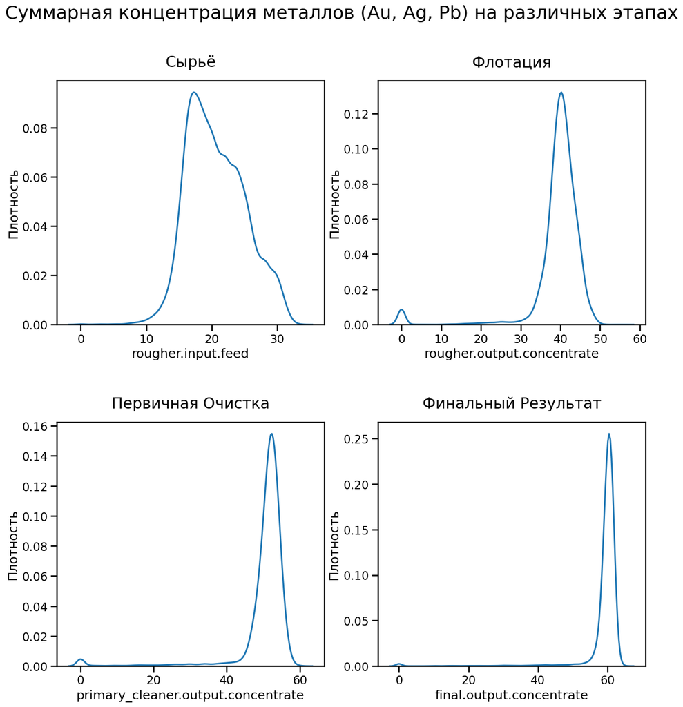

```python
f, axs = plt.subplots(2, 2, figsize=(15,15))
plt.subplots_adjust(hspace=.4)
plt.suptitle('Суммарная концентрация металлов (Au, Ag, Pb) на различных этапах', size='x-large')
for _, column, stage_ru in zip(range(4), metal_conc_sums_rows, metals_stages_list_ru):
    sns.kdeplot(metal_conc_sums_rows[column], ax=axs.flatten()[_])
    axs.flatten()[_].set_title(stage_ru)
    axs.flatten()[_].set_ylabel('Плотность')
```

**Выводы**

Говоря о содержании металлов в целом, мы видим что по ходу обработки оно увеличивается и распределение становится более остроконечным, а значит имеет меньший разброс, также на графиках видно аномальное значение 0 содержания элементов - обработанное ранее для выборок. Здесь оно сохраняется, т.к. изменения вносились непосредственно в выборки.

### 2.6. Итоги Анализа

Данные разделены на выборки по дате сбора и имеет место некоторое искажение результатов обработки, скорее всего связанное с различиями распределений размеров гранул сырья. Стоит учесть это при использовании модели в производственных условиях, возможно придётся периодически переобучать модель в случае если будут изменения в особенностях сырья.

В целом анализ показал, что технический процесс оправдан, на каждом шаге увеличивается содержание золота в концентрате. Стоит обратить внимание, что содержание серебра падает, что говорит о том что процесс выстроен для получения только золота, возможно оправданно обработать отходы процесса для извлечения из них серебра поскольку в исходных материалах содержание этих драгоценных металлов довольно близкое.

Также примечательно что в процессе обработки концентрат становится болел однородным и тем самым упрощается его дальнейшее использование, а значит улучшается стоимость.

Данные содержат ряд аномалий в содержании элементов в концентрате на всех стадиях кроме исходного сырья, это вызывает ошибки в расчётах сложно с уверенностью говорить об их причинах, однако возможно следует провести диагностику оборудования и/или процесса оценки содержания сырья дабы устранить сбой. Учитывая маленькое количество и то что аномалия всегда 0, сбой при переносе данных кажется менее вероятным.

## 3. Модель

3. Постройте модель

### 3.1. Выборки

```python
def reap_samples (complete):
    features_final = complete.drop(['final.output.recovery', 'rougher.output.recovery'], axis=1)
    features_rough = contains_extractor(features_final, 'rougher')
    target_final = complete['final.output.recovery']
    target_rough = complete['rougher.output.recovery']

    return features_rough, features_final,  target_rough, target_final
```

```python
gi_train_feat_rough, gi_train_feat_final, gi_train_targ_rough, gi_train_targ_final = reap_samples(gi_train)
gi_test_feat_rough, gi_test_feat_final, gi_test_targ_rough, gi_test_targ_final = reap_samples(gi_test)
```

```python
gi_train_targ_rough = gi_train_targ_rough.dropna()
gi_train_feat_rough = gi_train_feat_rough.loc[gi_train_targ_rough.index, :]
```

**Выводы**

У нас два целевых признака, для `rougher.output.recovery` большинство признаков в выборках не применимо, поскольку в ходе процесса они относятся к шагам после завершения флотации, качество которой он описывает. Таким образом, нам потребовалось разбить выборки и цп на набора, один для флотации (`rougher.output.recovery`), один для очистки в целом (`final.output.recovery`). После этого отброшены строки в грубой обучающей выборке, где значение ЦП равно 0. Они не влияют на результат оценки финального восстановления, поэтому для него их отбрасывать не нужно.

### 3.2. StandardScaler

```python
scaler = StandardScaler()

scaler.fit(gi_train_feat_rough)
gi_train_feat_rough_scaled = scaler.transform(gi_train_feat_rough)
gi_test_feat_rough_scaled = scaler.transform(gi_test_feat_rough)

scaler.fit(gi_train_feat_final)
gi_train_feat_final_scaled = scaler.transform(gi_train_feat_final)
gi_test_feat_final_scaled = scaler.transform(gi_test_feat_final)
```

**Выводы**

Проведена стандартизация признаков.

### 3.3. Функция для вычисления итоговой sMAPE.

3.1. Напишите функцию для вычисления итоговой sMAPE.

```python
def sMAPE(y_true, y_pred):
    result =  np.abs(y_true - y_pred)
    result /= (np.abs(y_true) + np.abs(y_pred))/2
    result =  result.mean()*100
    return result

scorer = make_scorer(sMAPE, greater_is_better=False) # Для кросс валидации
```

```python
def sMAPE_total(rough_true, rough_pred, final_true, final_pred):
    result = .25 * sMAPE(rough_true, rough_pred) + .75 * sMAPE(final_true, final_pred)
    return result

def sMAPE_total_simple(smape_rough, smape_final):
    return .25 * smape_rough + .75 * smape_final
```

**Выводы**

Составлена функция sMAPE, далее с помощью `make_scorer` из `sklearn.metrics` сделан применимый при кросс валидации оценщик. Функции `sMAPE_total` и `sMAPE_total_simple` отвечают за посчёт финальной метрики качества на основе метрик обоих целевых признаков.

### 3.4. Кросс-валидация

3.2. Обучите разные модели и оцените их качество кросс-валидацией. Выберите лучшую модель и проверьте её на тестовой выборке. Опишите выводы.

```python
def cv_rough_score_mean (model_to_score):
    scores = cross_val_score(model, gi_train_feat_rough, gi_train_targ_rough,
                             scoring=scorer)
    return -scores.mean()
```

```python
def cv_final_score_mean (model_to_score):
    scores = cross_val_score(model, gi_train_feat_final, gi_train_targ_final,
                             scoring=scorer)
    return -scores.mean()
```

```python
def sMAPE_total_simple(smape_rough, smape_final): # Повторяю для наглядности
    return .25 * smape_rough + .75 * smape_final
```

```python
def model_cv_sMAPE_mean_w_total(model):
    start_time = time.time()
    cv_sMAPE_mean_rough = cv_rough_score_mean(model)
    print("Средний sMAPE оценки обогощения флотации", type(model).__name__, "при кросс-валидации ", cv_sMAPE_mean_rough)
    rough_time = time.time()
    print("Заняло", round(time.time() - start_time, 2), "секунд")
    cv_sMAPE_mean_final = cv_final_score_mean(model)
    print("Средний sMAPE оценки обогощения всего процесса", type(model).__name__, "при кросс-валидации ", cv_sMAPE_mean_final)
    print("Заняло", round(time.time() - rough_time, 2), "секунд")
    cv_sMAPE_mean_w_total = sMAPE_total_simple(cv_sMAPE_mean_rough, cv_sMAPE_mean_final)
    print('Взвешенный средний sMAPE оценки обогощения', type(model).__name__, "при кросс-валидации ", cv_sMAPE_mean_w_total)
    return cv_sMAPE_mean_rough, cv_sMAPE_mean_final, cv_sMAPE_mean_w_total
```

```python
%%time

model = LinearRegression()

lin_reg_cv_sMAPE_mean_rough, lin_reg_cv_sMAPE_mean_final, \
    lin_reg_cv_sMAPE_mean_w_total = model_cv_sMAPE_mean_w_total(model)

lin_reg_cv_sMAPE_mean_w_total
```

```
Средний sMAPE оценки обогощения флотации LinearRegression при кросс-валидации  6.120150009696966
Заняло 0.24 секунд
Средний sMAPE оценки обогощения всего процесса LinearRegression при кросс-валидации  8.899178983993778
Заняло 0.16 секунд
Взвешенный средний sMAPE оценки обогощения LinearRegression при кросс-валидации  8.204421740419575
CPU times: total: 406 ms
Wall time: 398 ms
```

```
8.204421740419575
```

```python
%%time

model = DecisionTreeRegressor()

base_tree_cv_sMAPE_mean_rough, base_tree_cv_sMAPE_mean_final, \
    base_tree_cv_sMAPE_mean_w_total = model_cv_sMAPE_mean_w_total(model)

base_tree_cv_sMAPE_mean_w_total
```

```
Средний sMAPE оценки обогощения флотации DecisionTreeRegressor при кросс-валидации  8.516768588201208
Заняло 2.28 секунд
Средний sMAPE оценки обогощения всего процесса DecisionTreeRegressor при кросс-валидации  13.748079850970361
Заняло 6.35 секунд
Взвешенный средний sMAPE оценки обогощения DecisionTreeRegressor при кросс-валидации  12.440252035278073
CPU times: total: 8.12 s
Wall time: 8.63 s
```

```
12.440252035278073
```

```python
%%time

model = RandomForestRegressor()

base_forest_cv_sMAPE_mean_rough, base_forest_cv_sMAPE_mean_final, \
    base_forest_cv_sMAPE_mean_w_total = model_cv_sMAPE_mean_w_total(model)

base_forest_cv_sMAPE_mean_w_total
```

```
Средний sMAPE оценки обогощения флотации RandomForestRegressor при кросс-валидации  6.160748147574192
Заняло 145.7 секунд
Средний sMAPE оценки обогощения всего процесса RandomForestRegressor при кросс-валидации  9.207807984702558
Заняло 376.84 секунд
Взвешенный средний sMAPE оценки обогощения RandomForestRegressor при кросс-валидации  8.446043025420467
CPU times: total: 8min 4s
Wall time: 8min 42s
```

```
8.446043025420467
```

```python
%%time

parameters = {'max_depth': [None, *list(range(1, 22, 5))],
              'min_samples_split' : list(range(2, 6)),
             }
model = DecisionTreeRegressor(random_state=0)
clf_rough = GridSearchCV(model, parameters, scoring=scorer) #classifier
clf_rough.fit(gi_train_feat_rough, gi_train_targ_rough)
print(clf_rough.best_params_)
hyper_tree_cv_sMAPE_mean_rough = -clf_rough.best_score_
print(hyper_tree_cv_sMAPE_mean_rough)
```

```
{'max_depth': 6, 'min_samples_split': 5}
6.691803455062642
CPU times: total: 28.9 s
Wall time: 35.9 s
```

```python
%%time

clf_final = GridSearchCV(model, parameters, scoring=scorer) #classifier
clf_final.fit(gi_train_feat_final, gi_train_targ_final)
print(clf_final.best_params_)
hyper_tree_cv_sMAPE_mean_final = -clf_final.best_score_
print(hyper_tree_cv_sMAPE_mean_final)
```

```
{'max_depth': 1, 'min_samples_split': 2}
8.75095518735716
CPU times: total: 1min 16s
Wall time: 1min 25s
```

```python
hyper_tree_cv_sMAPE_mean_w_total = sMAPE_total_simple(hyper_tree_cv_sMAPE_mean_rough, hyper_tree_cv_sMAPE_mean_final)
print(hyper_tree_cv_sMAPE_mean_w_total)
```

```
8.236167254283531
```

**Выводы**

Регрессия показала себя лучшей, дерево с перебором гиперпараметров показывает близкий результат, но имеет высокий риск переобучения и немного отстаёт. Возможно с перебором гиперпараметров удасться найти случайный лес который даёт более качественный результат, однако каждая итерация на кросс валидации заниамает слишком много времени чтобы это было оправдано.

Результат средней итоговой sMAPE на кросс валидации 8.2 %.

### 3.5. Контрольная выборка

```python
%%time

model = LinearRegression()

model.fit(gi_train_feat_rough, gi_train_targ_rough)
gi_test_pred_rough = model.predict(gi_test_feat_rough)

model.fit(gi_train_feat_final, gi_train_targ_final)
gi_test_pred_final = model.predict(gi_test_feat_final)

sMAPE_total(gi_test_targ_rough, gi_test_pred_rough, gi_test_targ_final, gi_test_pred_final)
```

```
CPU times: total: 46.9 ms
Wall time: 58.9 ms
```

```
6.77478638944184
```

**Выводы**

Результат средней итоговой sMAPE на контрольной выборке 6.77%. Результат даже лучше чем средний на кросс валидации, возможно из-за более равномерных данных.

### 3.6. Проверка на вменяемость

```python
%%time

model = DummyRegressor(strategy='mean')

dummy_cv_sMAPE_mean_rough, dummy_cv_sMAPE_mean_final, \
    dummy_cv_sMAPE_mean_w_total = model_cv_sMAPE_mean_w_total(model)

dummy_cv_sMAPE_mean_w_total
```

```
Средний sMAPE оценки обогощения флотации DummyRegressor при кросс-валидации  7.139200137817632
Заняло 0.02 секунд
Средний sMAPE оценки обогощения всего процесса DummyRegressor при кросс-валидации  9.372510297949251
Заняло 0.03 секунд
Взвешенный средний sMAPE оценки обогощения DummyRegressor при кросс-валидации  8.814182757916345
CPU times: total: 31.2 ms
Wall time: 54 ms
```

```
8.814182757916345
```

```python
%%time

model = DummyRegressor(strategy='median')

dummy_cv_sMAPE_mean_rough, dummy_cv_sMAPE_mean_final, \
    dummy_cv_sMAPE_mean_w_total = model_cv_sMAPE_mean_w_total(model)

dummy_cv_sMAPE_mean_w_total
```

```
Средний sMAPE оценки обогощения флотации DummyRegressor при кросс-валидации  6.9375990439615975
Заняло 0.02 секунд
Средний sMAPE оценки обогощения всего процесса DummyRegressor при кросс-валидации  9.33231308350057
Заняло 0.03 секунд
Взвешенный средний sMAPE оценки обогощения DummyRegressor при кросс-валидации  8.733634573615827
CPU times: total: 62.5 ms
Wall time: 53.5 ms
```

```
8.733634573615827
```

```python
%%time

model = DummyRegressor(strategy='median')

model.fit(gi_train_feat_rough, gi_train_targ_rough)
gi_test_pred_rough = model.predict(gi_test_feat_rough)

model.fit(gi_train_feat_final, gi_train_targ_final)
gi_test_pred_final = model.predict(gi_test_feat_final)

sMAPE_total(gi_test_targ_rough, gi_test_pred_rough, gi_test_targ_final, gi_test_pred_final)
```

```
CPU times: total: 0 ns
Wall time: 3.27 ms
```

```
8.118300233182584
```

```python
%%time

model = DummyRegressor(strategy='mean')

model.fit(gi_train_feat_rough, gi_train_targ_rough)
gi_test_pred_rough = model.predict(gi_test_feat_rough)

model.fit(gi_train_feat_final, gi_train_targ_final)
gi_test_pred_final = model.predict(gi_test_feat_final)

sMAPE_total(gi_test_targ_rough, gi_test_pred_rough, gi_test_targ_final, gi_test_pred_final)
```

```
CPU times: total: 0 ns
Wall time: 3 ms
```

```
8.305325559940787
```

**Выводы**

На кросс валидации `DummyRegressor` показал себя довольно неплохо, превзойдя базовое дерево, и приблизившись к другим моделям, что говорит об однородности данных и о не очень высоком качестве моделей. Однако на контрольной выборке, он значительно отстаёт, что оправдывает использование модели.

## 4. Заключение

Поставленную задачу удалось выполнить. В результате, в качестве модели выбрана линейная регрессия, учитывая большое количества признаков, при этом все из используемых - действительные числа, способность линейной регрессии учитывать их с помощью коэффициентов, позволила здесь ей показать хороший результат.

Данные изначально разбиты на выборки, что создаёт некоторые затруднения анализа, неслучайное (по дате) разбитие данных к тому же делает модель несколько менее устойчивой к новым данным, несмотря на это модель показала лучше качество на контрольной выборке чем на кросс валидации, скорее всего в связи с тем что в обучающей выборке больше выбросов.

Отсутствие детальной документации по признакам несколько осложняет принятие решений при переработке данных, и анализ в целом. В данных также есть ряд аномалий, в основном связанных с отсутствием информации о элементах в концентрате. В целом, несмотря на неслучайный выбор выборок, они достаточно близки, что позволяет модели качественно работать. Анализ также подтверждает эффективность процесса очистки в целом, и показывает значительное повышение содержания золота в концентрате на каждой стадии процесса.